# SUBMIT_09_12 pm extra test project 07282020_ HR MODEL USE ALL

Why Are People Happy or Not Happy At Their Employment, By Naeemah Aliya Small: naeemahaz@gmail.com

Hiring Model ipums@umn.edu Thu, Nov 28, 12:31 PM (2 days ago) to me Your Higher Ed extract is ready. To retrieve your data, codebook, and command files, go to the link below. Account: naeemahaz@gmail.com Extract: 2 Link: https://highered.ipums.org/highered-action/extract_requests/download Publications and research reports based on the Higher Ed database must cite it appropriately. The citation should include the following: Minnesota Population Center. IPUMS Higher Ed: Version 1.0 [dataset]. Minneapolis, MN: University of Minnesota, 2016. https://doi.org/10.18128/D100.V1.0 For policy briefs or articles in the popular press that use the Higher Ed database, we recommend that you cite the use of Higher Ed data as follows: Higher Ed, University of Minnesota, www.ipums.org Thank you for your support. Sincerely, The Higher Ed Team

```python
%matplotlib inline
import pandas as pd
import numpy as np
import csv
import pydotplus
from sklearn.ensemble import RandomForestClassifier
from sklearn.datasets import load_iris
from sklearn import tree
import collections
from sklearn.tree import DecisionTreeClassifier # Import Decision Tree Classifier
from sklearn.model_selection import train_test_split # Import train_test_split function
from sklearn import metrics #Import scikit-learn metrics module for accuracy calculation
import matplotlib.pyplot as plt
import pydotplus
import os
from sklearn import tree
from sklearn.preprocessing import StandardScaler
import seaborn as sns
from sklearn.preprocessing import LabelEncoder
enc = LabelEncoder()
from sklearn import preprocessing
from sklearn.tree import export_graphviz
from sklearn.externals.six import StringIO
from IPython.display import Image
import pydotplus
import graphviz

import os

from tqdm import tqdm_notebook as tqdm
import time
for i in tqdm(range(50)):
    time.sleep(0.1)
from bokeh.io import output_file, show
from bokeh.models import ColumnDataSource
from bokeh.palettes import Spectral6
from bokeh.plotting import figure
from bokeh.plotting import figure, show
from bokeh.io import output_file
from bokeh.models import ColumnDataSource, CategoricalColorMapper, Div
from bokeh.layouts import gridplot, column
from bokeh.io import output_file, output_notebook
from bokeh.plotting import figure, show
from bokeh.models import ColumnDataSource
from bokeh.layouts import row, column, gridplot
from bokeh.models.widgets import Tabs, Panel
from bokeh.plotting import figure, show
from bokeh.io import output_file
from bokeh.models import ColumnDataSource
import seaborn as sns
import matplotlib.pyplot as plt
import pydotplus as pydot
from sklearn import tree
from IPython.display import Image
from sklearn.ensemble import RandomForestClassifier
from sklearn import preprocessing
pd.set_option('display.width', 1000)
pd.set_option('display.max_columns', 1000)
pd.set_option('display.max_columns', 1000)
```

```python
empdata = pd.read_csv('employnewdb.csv')
perdata = pd.read_csv('persondata.csv')
edudata = pd.read_csv('education.csv')
```

```python
empdata.sample(5)
```

|  | REFID | YEAR | LABOR_STATUS | HOURS_WORKED | WEEKS_WORKED | HAVE_HEALTH_CARE | HAVE_PENSION | HAVE_PROFIT_SHARE | HAVE_VACATION | LOOKING_FOR_WORK | PARTTIME_BUT_WANT_FULLTIME | PARTTIME_FOR_FAMILY | PARTTIME_NOT_WANT | PARTTIME_NO_FULLTIME | PARTTIME_OTHER | PRINCIPAL_POSITION_RELATED_HIGH_DEGREE | PRINCIPAL_POSITION | PRINCIPAL_MAJOR_GROUP | EMPLOYER_SECTOR | EMPLOYER_SIZE | EMPLOYER_NEW_BUSINESS | EMPLOYER_GOVERNMENT | EMPLOYER_EDUCATION | EMPLOYER_FEDERAL_SUPPORT | EMPLOYER_DEFENSE | EMPLOYER_ENERGY | FEDERAL_HEALTH_SERVICES | FEDERAL_NIH | FEDERAL_NSF | … |
| --- | --- | --- | --- | --- | --- | --- | --- | --- | --- | --- | --- | --- | --- | --- | --- | --- | --- | --- | --- | --- | --- | --- | --- | --- | --- | --- | --- | --- | --- | --- |
| 80924 | E11705688 | 2013 | Not in the labor force | None | None | No | No | No | No | No | No | No | No | No | No | No | None | None | Other | None | No | No | No | No | No | No | No | No | No | … |
| 35999 | D09544048 | 2010 | Employed | Greater than 40 hours | 40-52 weeks | Yes | Yes | No | Yes | No | No | No | No | No | No | Somewhat related | Science and engineering pre-college teachers | Science and engineering related occupations | 2 year college or other school system | 100-499 employees | No | No | No | No | No | No | No | No | No | … |
| 36320 | D09572080 | 2010 | Employed | Greater than 40 hours | 40-52 weeks | Yes | Yes | No | Yes | No | No | No | No | No | No | Closely related | Other social scientists | Social and related scientists | Business or industry | 1000-4999 employees | No | No | No | No | No | No | No | No | No | … |
| 52747 | E11196102 | 2013 | Employed | Greater than 40 hours | 40-52 weeks | Yes | Yes | No | Yes | No | No | No | No | No | No | Closely related | Electrical or computer hardware engineers | Engineers | Business or industry | 25-99 employees | No | Yes | No | No | Yes | Yes | No | No | No | … |
| 27803 | B10053678 | 2010 | Employed | 36 - 40 hours | 40-52 weeks | Yes | Yes | No | Yes | No | No | No | No | No | No | Closely related | Biological and medical scientists | Biological, agricultural and other life scient... | Business or industry | 100-499 employees | No | No | No | No | No | No | No | No | No | … |

```python
perdata.sample(5)
```

|  | REFID | YEAR | AGE | GENDER | MINORITY | RACE | BIRTH_PLACE | US_CITIZENSHIP | US_CITIZEN_TYPE | TOTAL_CHILDREN |
| --- | --- | --- | --- | --- | --- | --- | --- | --- | --- | --- |
| 26744 | E11128873 | 2013 | 27 | Female | No | Asian | Not in the US | No | None | None |
| 17606 | D09470517 | 2010 | 34 | Female | Yes | Under-represented minorities | United States | Yes | Born in US or US territories | None |
| 69004 | 500331758 | 2010 | 37 | Male | No | Asian | Not in the US | Yes | By naturalization | None |
| 12653 | D09129451 | 2010 | 39 | Female | No | White | United States | Yes | Born in US or US territories | None |
| 78369 | 500415864 | 2010 | 45 | Male | No | White | Not in the US | Yes | By naturalization | One child |

```python
edudata.sample(5)
```

|  | Unnamed: 0 | REFID | YEAR | FIELD_MAJOR_GROUP_BACHELOR_DEGREE | HIGHEST_DEGREE | FIELD_MAJOR_HIGHEST_DEGREE | FIELD_MAJOR_GROUP_HIGHEST_DEGREE | RECENT_DEGREE | FIELD_MAJOR_RECENT_DEGREE | FIELD_MAJOR_GROUP_RECENT_DEGREE | STUDENT_STATUS | REASON_EDUCATION_ADVANCE_OPPORTUNITIES | REASON_EDUCATION_BEFORE_CAREER | REASON_EDUCATION_CHANGE_CAREER | REASON_EDUCATION_PERSONAL | REASON_EDUCATION_CERIFICATION | REASON_EDUCATION_BY_EMPLOYER | REASON_EDUCATION_ADVANCE_SKILL_IN_FIELD | REASON_EDUCATION_PAID_BY_EMPLOYER |
| --- | --- | --- | --- | --- | --- | --- | --- | --- | --- | --- | --- | --- | --- | --- | --- | --- | --- | --- | --- |
| 74931 | 179515 | E11600574 | 2013 | Engineering | Bachelor | Electrical, electronics and communications eng... | Engineering | Bachelor | Electrical, electronics and communications eng... | Engineering | None | No | No | No | No | No | No | No | No |
| 57098 | 161682 | E11279601 | 2013 | Social and related sciences | Bachelor | Political and related sciences | Social and related sciences | Bachelor | Political and related sciences | Social and related sciences | None | No | No | No | No | No | No | No | No |
| 88636 | 257559 | 2I938KK20 | 2010 | Science and engineering-related fields | Doctorate | Health-related fields | Science and engineering-related fields | No Degree | Health-related fields | Science and engineering-related fields | None | No | No | No | No | No | No | No | No |
| 80075 | 184659 | E11691813 | 2013 | Science and engineering-related fields | Bachelor | Other science and engineering-related | Science and engineering-related fields | Bachelor | Other science and engineering-related | Science and engineering-related fields | None | No | No | No | No | No | No | No | No |
| 33975 | 48868 | D09359314 | 2010 | Engineering | Bachelor | Other engineering | Engineering | Bachelor | Other engineering | Engineering | None | No | No | No | No | No | No | No | No |

```python
edudata.columns
```

```
Index(['Unnamed: 0', 'REFID', 'YEAR', 'FIELD_MAJOR_GROUP_BACHELOR_DEGREE', 'HIGHEST_DEGREE', 'FIELD_MAJOR_HIGHEST_DEGREE', 'FIELD_MAJOR_GROUP_HIGHEST_DEGREE', 'RECENT_DEGREE', 'FIELD_MAJOR_RECENT_DEGREE', 'FIELD_MAJOR_GROUP_RECENT_DEGREE', 'STUDENT_STATUS', 'REASON_EDUCATION_ADVANCE_OPPORTUNITIES', …
```

```python
edudata = edudata[['REFID', 'YEAR', 'FIELD_MAJOR_GROUP_BACHELOR_DEGREE', 'HIGHEST_DEGREE', 'FIELD_MAJOR_HIGHEST_DEGREE', 'FIELD_MAJOR_GROUP_HIGHEST_DEGREE', 'RECENT_DEGREE', 'FIELD_MAJOR_RECENT_DEGREE', 'FIELD_MAJOR_GROUP_RECENT_DEGREE', 'STUDENT_STATUS', 'REASON_EDUCATION_ADVANCE_OPPORTUNITIES', 'REASON_EDUCATION_BEFORE_CAREER', 'REASON_EDUCATION_CHANGE_CAREER', 'REASON_EDUCATION_PERSONAL', 'REASON_EDUCATION_CERIFICATION', 'REASON_EDUCATION_BY_EMPLOYER', 'REASON_EDUCATION_ADVANCE_SKILL_IN_FIELD', 'REASON_EDUCATION_PAID_BY_EMPLOYER']]
```

```python
edudata.sample(5)
```

|  | REFID | YEAR | FIELD_MAJOR_GROUP_BACHELOR_DEGREE | HIGHEST_DEGREE | FIELD_MAJOR_HIGHEST_DEGREE | FIELD_MAJOR_GROUP_HIGHEST_DEGREE | RECENT_DEGREE | FIELD_MAJOR_RECENT_DEGREE | FIELD_MAJOR_GROUP_RECENT_DEGREE | STUDENT_STATUS | REASON_EDUCATION_ADVANCE_OPPORTUNITIES | REASON_EDUCATION_BEFORE_CAREER | REASON_EDUCATION_CHANGE_CAREER | REASON_EDUCATION_PERSONAL | REASON_EDUCATION_CERIFICATION | REASON_EDUCATION_BY_EMPLOYER | REASON_EDUCATION_ADVANCE_SKILL_IN_FIELD | REASON_EDUCATION_PAID_BY_EMPLOYER |
| --- | --- | --- | --- | --- | --- | --- | --- | --- | --- | --- | --- | --- | --- | --- | --- | --- | --- | --- |
| 71133 | E11534294 | 2013 | Science and engineering-related fields | Bachelor | Other science and engineering-related | Science and engineering-related fields | Bachelor | Other science and engineering-related | Science and engineering-related fields | None | No | No | No | No | No | No | No | No |
| 25691 | A06469399 | 2010 | Computer and mathematical sciences | Master | Computer and mathematical science | Computer and mathematical sciences | Master | Computer and mathematical science | Computer and mathematical sciences | None | No | No | No | No | No | No | No | No |
| 69008 | E11496163 | 2013 | Engineering | Master | Electrical, electronics and communications eng... | Engineering | Master | Electrical, electronics and communications eng... | Engineering | None | No | No | No | No | No | No | No | No |
| 53407 | E11208428 | 2013 | Non-science and engineering fields | Master | Psychology | Social and related sciences | Master | Psychology | Social and related sciences | None | No | No | No | No | No | No | No | No |
| 13792 | 500427838 | 2010 | Social and related sciences | Professional | Other non-science and engineering | Non-science and engineering fields | Professional | Other non-science and engineering | Non-science and engineering fields | None | No | No | No | No | No | No | No | No |

```python
allnewdataperedu = pd.merge(left=perdata, right=edudata, left_on='REFID', right_on='REFID')
```

```python
allnewdataperedu.sample(5)
```

|  | REFID | YEAR_x | AGE | GENDER | MINORITY | RACE | BIRTH_PLACE | US_CITIZENSHIP | US_CITIZEN_TYPE | TOTAL_CHILDREN | YEAR_y | FIELD_MAJOR_GROUP_BACHELOR_DEGREE | HIGHEST_DEGREE | FIELD_MAJOR_HIGHEST_DEGREE | FIELD_MAJOR_GROUP_HIGHEST_DEGREE | RECENT_DEGREE | FIELD_MAJOR_RECENT_DEGREE | FIELD_MAJOR_GROUP_RECENT_DEGREE | STUDENT_STATUS | REASON_EDUCATION_ADVANCE_OPPORTUNITIES | REASON_EDUCATION_BEFORE_CAREER | REASON_EDUCATION_CHANGE_CAREER | REASON_EDUCATION_PERSONAL | REASON_EDUCATION_CERIFICATION | REASON_EDUCATION_BY_EMPLOYER | REASON_EDUCATION_ADVANCE_SKILL_IN_FIELD | REASON_EDUCATION_PAID_BY_EMPLOYER |
| --- | --- | --- | --- | --- | --- | --- | --- | --- | --- | --- | --- | --- | --- | --- | --- | --- | --- | --- | --- | --- | --- | --- | --- | --- | --- | --- | --- |
| 82298 | 500453543 | 2010 | 53 | Male | No | White | United States | Yes | Born in US or US territories | None | 2010 | Social and related sciences | Master | Political and related sciences | Social and related sciences | Master | Political and related sciences | Social and related sciences | None | No | No | No | No | No | No | No | No |
| 23719 | E11071354 | 2013 | 28 | Male | No | White | United States | Yes | Born in US or US territories | None | 2013 | Computer and mathematical sciences | Bachelor | Computer and mathematical science | Computer and mathematical sciences | Bachelor | Computer and mathematical science | Computer and mathematical sciences | Part-Time | Yes | Yes | Yes | Yes | Yes | Yes | Yes | No |
| 15736 | D09343888 | 2013 | 28 | Female | No | White | United States | Yes | Born in US or US territories | Two or more children | 2013 | Science and engineering-related fields | Master | Health-related fields | Science and engineering-related fields | Master | Health-related fields | Science and engineering-related fields | None | No | No | No | No | No | No | No | No |
| 60454 | E11736493 | 2013 | 41 | Female | Yes | Under-represented minorities | Not in the US | Yes | By naturalization | None | 2013 | Non-science and engineering fields | Bachelor | Health-related fields | Science and engineering-related fields | Bachelor | Health-related fields | Science and engineering-related fields | None | No | No | No | No | No | No | No | No |
| 65740 | E11828753 | 2013 | 27 | Male | No | White | Not in the US | No | None | None | 2013 | Biological, agricultural and environmental lif... | Bachelor | Biological sciences | Biological, agricultural and environmental lif... | Bachelor | Biological sciences | Biological, agricultural and environmental lif... | None | No | No | No | No | No | No | No | No |

```python
allnewdatame = pd.merge(left=allnewdataperedu, right=empdata, left_on='REFID', right_on='REFID')
```

```python
allnewdatame.sample(5)
```

|  | REFID | YEAR_x | AGE | GENDER | MINORITY | RACE | BIRTH_PLACE | US_CITIZENSHIP | US_CITIZEN_TYPE | TOTAL_CHILDREN | YEAR_y | FIELD_MAJOR_GROUP_BACHELOR_DEGREE | HIGHEST_DEGREE | FIELD_MAJOR_HIGHEST_DEGREE | FIELD_MAJOR_GROUP_HIGHEST_DEGREE | RECENT_DEGREE | FIELD_MAJOR_RECENT_DEGREE | FIELD_MAJOR_GROUP_RECENT_DEGREE | STUDENT_STATUS | REASON_EDUCATION_ADVANCE_OPPORTUNITIES | REASON_EDUCATION_BEFORE_CAREER | REASON_EDUCATION_CHANGE_CAREER | REASON_EDUCATION_PERSONAL | REASON_EDUCATION_CERIFICATION | REASON_EDUCATION_BY_EMPLOYER | REASON_EDUCATION_ADVANCE_SKILL_IN_FIELD | REASON_EDUCATION_PAID_BY_EMPLOYER | YEAR | LABOR_STATUS | … |
| --- | --- | --- | --- | --- | --- | --- | --- | --- | --- | --- | --- | --- | --- | --- | --- | --- | --- | --- | --- | --- | --- | --- | --- | --- | --- | --- | --- | --- | --- | --- |
| 68473 | 500476832 | 2010 | 75 | Male | No | White | United States | Yes | Born in US or US territories | None | 2010 | Physical and related sciences | Bachelor | Chemistry, except biochemistry | Physical and related sciences | Bachelor | Chemistry, except biochemistry | Physical and related sciences | None | No | No | No | No | No | No | No | No | 2010 | Not in the labor force | … |
| 69683 | 500487386 | 2010 | 73 | Male | No | White | United States | Yes | Born in US or US territories | None | 2010 | Computer and mathematical sciences | Bachelor | Computer and mathematical science | Computer and mathematical sciences | Bachelor | Computer and mathematical science | Computer and mathematical sciences | None | No | No | No | No | No | No | No | No | 2010 | Not in the labor force | … |
| 36789 | E11317062 | 2013 | 45 | Male | No | White | United States | Yes | Born in US or US territories | None | 2013 | Computer and mathematical sciences | Master | Computer and mathematical science | Computer and mathematical sciences | Master | Computer and mathematical science | Computer and mathematical sciences | None | No | No | No | No | No | No | No | No | 2013 | Employed | … |
| 44250 | E11453065 | 2013 | 40 | Female | No | White | United States | Yes | Born in US or US territories | Two or more children | 2013 | Non-science and engineering fields | Master | Other science and engineering-related | Science and engineering-related fields | Master | Other science and engineering-related | Science and engineering-related fields | None | No | No | No | No | No | No | No | No | 2013 | Employed | … |
| 29570 | E11181344 | 2013 | 58 | Female | No | White | United States | Yes | Born in US or US territories | None | 2013 | Science and engineering-related fields | Bachelor | Health-related fields | Science and engineering-related fields | Bachelor | Health-related fields | Science and engineering-related fields | None | No | No | No | No | No | No | No | No | 2013 | Employed | … |

```python
print(allnewdatame.columns.values)
```

```
['REFID' 'YEAR_x' 'AGE' 'GENDER' 'MINORITY' 'RACE' 'BIRTH_PLACE'
 'US_CITIZENSHIP' 'US_CITIZEN_TYPE' 'TOTAL_CHILDREN' 'YEAR_y'
 'FIELD_MAJOR_GROUP_BACHELOR_DEGREE' 'HIGHEST_DEGREE'
 'FIELD_MAJOR_HIGHEST_DEGREE' 'FIELD_MAJOR_GROUP_HIGHEST_DEGREE'
 'RECENT_DEGREE' 'FIELD_MAJOR_RECENT_DEGREE'
 'FIELD_MAJOR_GROUP_RECENT_DEGREE' 'STUDENT_STATUS'
 'REASON_EDUCATION_ADVANCE_OPPORTUNITIES' 'REASON_EDUCATION_BEFORE_CAREER'
 'REASON_EDUCATION_CHANGE_CAREER' 'REASON_EDUCATION_PERSONAL'
 'REASON_EDUCATION_CERIFICATION' 'REASON_EDUCATION_BY_EMPLOYER'
 'REASON_EDUCATION_ADVANCE_SKILL_IN_FIELD'
 'REASON_EDUCATION_PAID_BY_EMPLOYER' 'YEAR' 'LABOR_STATUS' 'HOURS_WORKED'
 'WEEKS_WORKED' 'HAVE_HEALTH_CARE' 'HAVE_PENSION' 'HAVE_PROFIT_SHARE'
 'HAVE_VACATION' 'LOOKING_FOR_WORK' 'PARTTIME_BUT_WANT_FULLTIME'
 'PARTTIME_FOR_FAMILY' 'PARTTIME_NOT_WANT' 'PARTTIME_NO_FULLTIME'
 'PARTTIME_OTHER' 'PRINCIPAL_POSITION_RELATED_HIGH_DEGREE'
 'PRINCIPAL_POSITION' 'PRINCIPAL_MAJOR_GROUP' 'EMPLOYER_SECTOR'
 'EMPLOYER_SIZE' 'EMPLOYER_NEW_BUSINESS' 'EMPLOYER_GOVERNMENT'
 'EMPLOYER_EDUCATION' 'EMPLOYER_FEDERAL_SUPPORT' 'EMPLOYER_DEFENSE'
 'EMPLOYER_ENERGY' 'FEDERAL_HEALTH_SERVICES' 'FEDERAL_NIH' 'FEDERAL_NSF'
 'FEDERAL_OTHER' 'WORK_ACTIVITY' 'WORK_ACTIVITY_SUM'
 'WORK_ACTIVITY_SECOND' 'WORK_ACTIVITY_SCEOND_SUM' 'COMPUTER'
 'DEVELOPMENT_AND_DESIGN' 'MANAGEMENT_SALES' 'RESEARCH_AND_DEVELOPMENT'
 'RESEARCH_DEVE_TEACHING' 'ACTIVITY_RESEARCH' 'ACTIVITY_TEACHING'
 'WORK_DEVELOPMENT' 'WORK_DESIGN' 'WORK_EMPLOYEE_RELATIONS'
 'WORK_MANAGEMENT_ADMIN' 'WORK_OTHER' 'WORK_PRODUCTION'
 'WORK_QUALITY_MANAGEMENT' 'WORK_SALES_MARKETING'
 'WORK_PROFESSIONAL_SERVICES' 'WORK_TEACHING' 'WORK_FINANCE'
 'WORK_APPLIED_RESEARCH' 'WORK_RESEARCH' 'WORK_COMPUTER_APPLICATIONS'
 'SUPERVISORY_WORK' 'MEMEBERSHIP' 'ATTENED_PROFESSIONAL_MEET' ' SALARY '
 'WORK_OUTSIDE_DEGREE_FOR_FIRST_REASON'
 'WORK_OUTSIDE_DEGREE_FOR_SECOND_REASON'
 'WORK_OUTSIDE_DEGREE_FOR_CAREER_CHANGE'
 'WORK_OUTSIDE_DEGREE_FOR_WORK_COND' 'WORK_OUTSIDE_DEGREE_FOR_FAMILY'
 'WORK_OUTSIDE_DEGREE_FOR_LOC' 'WORK_OUTSIDE_DEGREE_FOR_NOT_AVAIL'
 'WORK_OUTSIDE_DEGREE_FOR_OTHER' 'WORK_OUTSIDE_DEGREE_FOR_PAY_PROMOTE'
 'SATISFACTION_JOB' 'SATISFACTION_JOB_ADVANCE' 'SATISFACTION_JOB_BENEFITS'
 'SATISFACTION_JOB_CHALLENGE' 'SATISFACTION_JOB_INDEP'
 'SATISFACTION_JOB_LOC' 'SATISFACTION_JOB_RESP' 'SATISFACTION_JOB_SALARY'
 'SATISFACTION_JOB_SECURITY' 'SATISFACTION_JOB_CONTRIB_SOCIETY'
 'ATTEND_TRAINING_WORK_RELATE' 'ATTEND_TRAINING'
 'ATTEND_TRAINING_CHANGE_FIELD' 'ATTEND_TRAINING_BY_EMPLOYER'
 'ATTEND_TRAINING_CERT' 'ATTEND_TRAINING_INCREASE_ADV_CUR'
 'ATTEND_TRAINING_OTHER' 'ATTEND_TRAINING_PERSONAL'
 'ATTEND_TRAINING_ACQUIRE_SKILL' 'JOB_REQUIRED_TECH_NATURAL_SCIENCES'
 'JOB_REQUIRED_TECH_OTHER' 'JOB_REQUIRED_TECH_SOCIAL_SCIENCES'
 'NOT_WORKING_LAYOFF' 'NOT_WORKING_NO_NEED_TO_WORK' 'NOT_WORKING_NO_JOB'
 'NOT_WORKING_SICK' 'NOT_WORKING_STUDENT']
```

```python
allnewdatanow = allnewdatame[['REFID', 'YEAR', 'AGE', 'GENDER', 'RACE', 'BIRTH_PLACE',
 'US_CITIZENSHIP','US_CITIZEN_TYPE','TOTAL_CHILDREN',
 'FIELD_MAJOR_GROUP_BACHELOR_DEGREE','HIGHEST_DEGREE',
 'FIELD_MAJOR_HIGHEST_DEGREE','FIELD_MAJOR_GROUP_HIGHEST_DEGREE',
 'RECENT_DEGREE','FIELD_MAJOR_RECENT_DEGREE',
 'FIELD_MAJOR_GROUP_RECENT_DEGREE','STUDENT_STATUS',
 'REASON_EDUCATION_ADVANCE_OPPORTUNITIES','REASON_EDUCATION_BEFORE_CAREER',
 'REASON_EDUCATION_CHANGE_CAREER','REASON_EDUCATION_PERSONAL',
 'REASON_EDUCATION_CERIFICATION','REASON_EDUCATION_BY_EMPLOYER',
 'REASON_EDUCATION_ADVANCE_SKILL_IN_FIELD',
 'REASON_EDUCATION_PAID_BY_EMPLOYER','LABOR_STATUS','HOURS_WORKED',
 'WEEKS_WORKED','HAVE_HEALTH_CARE','HAVE_PENSION','HAVE_PROFIT_SHARE',
 'HAVE_VACATION','LOOKING_FOR_WORK','PARTTIME_BUT_WANT_FULLTIME',
 'PARTTIME_FOR_FAMILY','PARTTIME_NOT_WANT','PARTTIME_NO_FULLTIME',
 'PARTTIME_OTHER','PRINCIPAL_POSITION_RELATED_HIGH_DEGREE',
 'PRINCIPAL_POSITION','PRINCIPAL_MAJOR_GROUP','EMPLOYER_SECTOR',
 'EMPLOYER_SIZE','EMPLOYER_NEW_BUSINESS','EMPLOYER_GOVERNMENT',
 'EMPLOYER_EDUCATION','EMPLOYER_FEDERAL_SUPPORT' ,'EMPLOYER_DEFENSE',
 'EMPLOYER_ENERGY', 'FEDERAL_HEALTH_SERVICES' ,'FEDERAL_NIH', 'FEDERAL_NSF',
 'FEDERAL_OTHER', 'WORK_ACTIVITY', 'WORK_ACTIVITY_SUM',
 'WORK_ACTIVITY_SECOND', 'WORK_ACTIVITY_SCEOND_SUM', 'COMPUTER',
 'DEVELOPMENT_AND_DESIGN', 'MANAGEMENT_SALES', 'RESEARCH_AND_DEVELOPMENT',
 'RESEARCH_DEVE_TEACHING' ,'ACTIVITY_RESEARCH', 'ACTIVITY_TEACHING',
 'WORK_DEVELOPMENT', 'WORK_DESIGN', 'WORK_EMPLOYEE_RELATIONS',
 'WORK_MANAGEMENT_ADMIN', 'WORK_OTHER', 'WORK_PRODUCTION',
 'WORK_QUALITY_MANAGEMENT', 'WORK_SALES_MARKETING',
 'WORK_PROFESSIONAL_SERVICES', 'WORK_TEACHING', 'WORK_FINANCE',
 'WORK_APPLIED_RESEARCH' ,'WORK_RESEARCH', 'WORK_COMPUTER_APPLICATIONS',
 'SUPERVISORY_WORK', 'MEMEBERSHIP', 'ATTENED_PROFESSIONAL_MEET', ' SALARY ',
 'WORK_OUTSIDE_DEGREE_FOR_FIRST_REASON',
 'WORK_OUTSIDE_DEGREE_FOR_SECOND_REASON',
 'WORK_OUTSIDE_DEGREE_FOR_CAREER_CHANGE',
 'WORK_OUTSIDE_DEGREE_FOR_WORK_COND', 'WORK_OUTSIDE_DEGREE_FOR_FAMILY',
 'WORK_OUTSIDE_DEGREE_FOR_LOC', 'WORK_OUTSIDE_DEGREE_FOR_NOT_AVAIL',
 'WORK_OUTSIDE_DEGREE_FOR_OTHER', 'WORK_OUTSIDE_DEGREE_FOR_PAY_PROMOTE',
 'SATISFACTION_JOB', 'SATISFACTION_JOB_ADVANCE', 'SATISFACTION_JOB_BENEFITS',
 'SATISFACTION_JOB_CHALLENGE' , 'SATISFACTION_JOB_INDEP',
 'SATISFACTION_JOB_LOC', 'SATISFACTION_JOB_RESP', 'SATISFACTION_JOB_SALARY',
 'SATISFACTION_JOB_SECURITY', 'SATISFACTION_JOB_CONTRIB_SOCIETY',
 'ATTEND_TRAINING_WORK_RELATE', 'ATTEND_TRAINING',
 'ATTEND_TRAINING_CHANGE_FIELD', 'ATTEND_TRAINING_BY_EMPLOYER',
 'ATTEND_TRAINING_CERT', 'ATTEND_TRAINING_INCREASE_ADV_CUR',
 'ATTEND_TRAINING_OTHER', 'ATTEND_TRAINING_PERSONAL',
 'ATTEND_TRAINING_ACQUIRE_SKILL', 'JOB_REQUIRED_TECH_NATURAL_SCIENCES',
 'JOB_REQUIRED_TECH_OTHER', 'JOB_REQUIRED_TECH_SOCIAL_SCIENCES',
 'NOT_WORKING_LAYOFF', 'NOT_WORKING_NO_NEED_TO_WORK','NOT_WORKING_NO_JOB',
 'NOT_WORKING_SICK', 'NOT_WORKING_STUDENT']]
```

```python
allnewdatanow.sample(5)
```

|  | REFID | YEAR | AGE | GENDER | RACE | BIRTH_PLACE | US_CITIZENSHIP | US_CITIZEN_TYPE | TOTAL_CHILDREN | FIELD_MAJOR_GROUP_BACHELOR_DEGREE | HIGHEST_DEGREE | FIELD_MAJOR_HIGHEST_DEGREE | FIELD_MAJOR_GROUP_HIGHEST_DEGREE | RECENT_DEGREE | FIELD_MAJOR_RECENT_DEGREE | FIELD_MAJOR_GROUP_RECENT_DEGREE | STUDENT_STATUS | REASON_EDUCATION_ADVANCE_OPPORTUNITIES | REASON_EDUCATION_BEFORE_CAREER | REASON_EDUCATION_CHANGE_CAREER | REASON_EDUCATION_PERSONAL | REASON_EDUCATION_CERIFICATION | REASON_EDUCATION_BY_EMPLOYER | REASON_EDUCATION_ADVANCE_SKILL_IN_FIELD | REASON_EDUCATION_PAID_BY_EMPLOYER | LABOR_STATUS | HOURS_WORKED | WEEKS_WORKED | HAVE_HEALTH_CARE | … |
| --- | --- | --- | --- | --- | --- | --- | --- | --- | --- | --- | --- | --- | --- | --- | --- | --- | --- | --- | --- | --- | --- | --- | --- | --- | --- | --- | --- | --- | --- | --- |
| 25869 | E11112612 | 2013 | 46 | Female | Under-represented minorities | United States | Yes | Born in US or US territories | None | Computer and mathematical sciences | Bachelor | Computer and mathematical science | Computer and mathematical sciences | Bachelor | Computer and mathematical science | Computer and mathematical sciences | None | No | No | No | No | No | No | No | No | Employed | 20 or less | 40-52 weeks | No | … |
| 29326 | E11177102 | 2013 | 27 | Male | White | Not in the US | No | None | None | Social and related sciences | Master | Economics | Social and related sciences | Master | Economics | Social and related sciences | Part-Time | Yes | Yes | No | No | No | No | Yes | No | Employed | 20 or less | 40-52 weeks | Yes | … |
| 26551 | E11125408 | 2013 | 27 | Male | White | United States | Yes | Born in US or US territories | None | Engineering | Bachelor | Mechanical engineering | Engineering | Bachelor | Mechanical engineering | Engineering | None | No | No | No | No | No | No | No | No | Employed | Greater than 40 hours | 40-52 weeks | Yes | … |
| 25422 | E11104049 | 2013 | 53 | Male | Under-represented minorities | United States | Yes | Born in US or US territories | Two or more children | Engineering | Bachelor | Electrical, electronics and communications eng... | Engineering | Bachelor | Electrical, electronics and communications eng... | Engineering | None | No | No | No | No | No | No | No | No | Employed | 36 - 40 hours | 40-52 weeks | Yes | … |
| 8782 | C10080450 | 2010 | 29 | Male | White | United States | Yes | Born in US or US territories | None | Engineering | Master | Other engineering | Engineering | Master | Other engineering | Engineering | Full-Time | Yes | Yes | No | No | No | No | No | No | Not in the labor force | None | None | No | … |

```python
allnewdatanow.info()
```

```
<class 'pandas.core.frame.DataFrame'>
Int64Index: 73292 entries, 0 to 73291
Columns: 118 entries, REFID to NOT_WORKING_STUDENT
dtypes: int64(2), object(116)
memory usage: 66.5+ MB
```

```python
allnewdatanow['AGE'] = pd.to_numeric(allnewdatanow['AGE'])
```

```python
bins = [20, 30,  40,  50,  60,  70,  80]
allnewdatanow['AGE_BINS'] = pd.cut(allnewdatanow['AGE'], bins)
```

```python
allnewdatanow[' SALARY '] = allnewdatanow[' SALARY '].fillna(0)
```

```python
allnewdatanow['SALARY_NEW'] = allnewdatanow[' SALARY '].str.replace('$', '')
```

```python
allnewdatanow['SALARY_NEW'] = allnewdatanow['SALARY_NEW'].str.replace(',', '')
```

```python
allnewdatanow['SALARY'] = allnewdatanow['SALARY_NEW'].str.replace(' -   ', '')
```

```python
allnewdatanow = allnewdatanow.drop('SALARY_NEW', axis=1)
```

```python
allnewdatanow['SALARY'] = pd.to_numeric(allnewdatanow['SALARY'], errors='coerce')
```

```python
bins = [0,  39999,  40000, 79999,  80000,  200000]
allnewdatanow['SALARY_BINS'] = pd.cut(allnewdatanow['SALARY'], bins)
```

```python
allnewdatanow = allnewdatanow.drop('SALARY', axis=1)
```

```python
allnewdatanow = allnewdatanow.drop(' SALARY ', axis=1)
```

```python
allnewdatanow.sample(5)
```

|  | REFID | YEAR | AGE | GENDER | RACE | BIRTH_PLACE | US_CITIZENSHIP | US_CITIZEN_TYPE | TOTAL_CHILDREN | FIELD_MAJOR_GROUP_BACHELOR_DEGREE | HIGHEST_DEGREE | FIELD_MAJOR_HIGHEST_DEGREE | FIELD_MAJOR_GROUP_HIGHEST_DEGREE | RECENT_DEGREE | FIELD_MAJOR_RECENT_DEGREE | FIELD_MAJOR_GROUP_RECENT_DEGREE | STUDENT_STATUS | REASON_EDUCATION_ADVANCE_OPPORTUNITIES | REASON_EDUCATION_BEFORE_CAREER | REASON_EDUCATION_CHANGE_CAREER | REASON_EDUCATION_PERSONAL | REASON_EDUCATION_CERIFICATION | REASON_EDUCATION_BY_EMPLOYER | REASON_EDUCATION_ADVANCE_SKILL_IN_FIELD | REASON_EDUCATION_PAID_BY_EMPLOYER | LABOR_STATUS | HOURS_WORKED | WEEKS_WORKED | HAVE_HEALTH_CARE | … |
| --- | --- | --- | --- | --- | --- | --- | --- | --- | --- | --- | --- | --- | --- | --- | --- | --- | --- | --- | --- | --- | --- | --- | --- | --- | --- | --- | --- | --- | --- | --- |
| 53444 | E11616349 | 2013 | 32 | Male | White | Not in the US | No | None | None | NaN | Master | Computer and mathematical science | Computer and mathematical sciences | Master | Computer and mathematical science | Computer and mathematical sciences | None | No | No | No | No | No | No | No | No | Employed | 36 - 40 hours | 40-52 weeks | Yes | … |
| 65683 | E11827821 | 2013 | 27 | Female | White | United States | Yes | Born in US or US territories | None | Social and related sciences | Master | Psychology | Social and related sciences | Master | Psychology | Social and related sciences | None | No | No | No | No | No | No | No | No | Employed | Greater than 40 hours | 40-52 weeks | Yes | … |
| 44035 | E11449048 | 2013 | 32 | Female | Under-represented minorities | United States | Yes | Born in US or US territories | Two or more children | Social and related sciences | Master | Other non-science and engineering | Non-science and engineering fields | Master | Other non-science and engineering | Non-science and engineering fields | None | No | No | No | No | No | No | No | No | Employed | Greater than 40 hours | 40-52 weeks | Yes | … |
| 28380 | E11159225 | 2013 | 42 | Male | White | United States | Yes | Born in US or US territories | Two or more children | Engineering | Master | Electrical, electronics and communications eng... | Engineering | Master | Electrical, electronics and communications eng... | Engineering | None | No | No | No | No | No | No | No | No | Employed | Greater than 40 hours | 40-52 weeks | Yes | … |
| 60994 | E11746328 | 2013 | 33 | Female | White | United States | Yes | Born in US or US territories | None | Social and related sciences | Master | Health-related fields | Science and engineering-related fields | Master | Health-related fields | Science and engineering-related fields | None | No | No | No | No | No | No | No | No | Unemployed | None | None | No | … |

```python
allnewdatanow = allnewdatanow.drop(['STUDENT_STATUS','LABOR_STATUS','LOOKING_FOR_WORK','PARTTIME_BUT_WANT_FULLTIME','PARTTIME_FOR_FAMILY','PARTTIME_NOT_WANT','PARTTIME_NO_FULLTIME','PARTTIME_OTHER','JOB_REQUIRED_TECH_NATURAL_SCIENCES','JOB_REQUIRED_TECH_OTHER','JOB_REQUIRED_TECH_SOCIAL_SCIENCES','NOT_WORKING_LAYOFF','NOT_WORKING_NO_NEED_TO_WORK','NOT_WORKING_NO_JOB','NOT_WORKING_SICK','NOT_WORKING_STUDENT'], axis=1)
```

```python
allnewdatanow.sample(5)
```

|  | REFID | YEAR | AGE | GENDER | RACE | BIRTH_PLACE | US_CITIZENSHIP | US_CITIZEN_TYPE | TOTAL_CHILDREN | FIELD_MAJOR_GROUP_BACHELOR_DEGREE | HIGHEST_DEGREE | FIELD_MAJOR_HIGHEST_DEGREE | FIELD_MAJOR_GROUP_HIGHEST_DEGREE | RECENT_DEGREE | FIELD_MAJOR_RECENT_DEGREE | FIELD_MAJOR_GROUP_RECENT_DEGREE | REASON_EDUCATION_ADVANCE_OPPORTUNITIES | REASON_EDUCATION_BEFORE_CAREER | REASON_EDUCATION_CHANGE_CAREER | REASON_EDUCATION_PERSONAL | REASON_EDUCATION_CERIFICATION | REASON_EDUCATION_BY_EMPLOYER | REASON_EDUCATION_ADVANCE_SKILL_IN_FIELD | REASON_EDUCATION_PAID_BY_EMPLOYER | HOURS_WORKED | WEEKS_WORKED | HAVE_HEALTH_CARE | HAVE_PENSION | HAVE_PROFIT_SHARE | … |
| --- | --- | --- | --- | --- | --- | --- | --- | --- | --- | --- | --- | --- | --- | --- | --- | --- | --- | --- | --- | --- | --- | --- | --- | --- | --- | --- | --- | --- | --- | --- |
| 27033 | E11134442 | 2013 | 44 | Male | White | United States | Yes | Born in US or US territories | Two or more children | Social and related sciences | Bachelor | Psychology | Social and related sciences | Bachelor | Psychology | Social and related sciences | No | No | No | No | No | No | No | No | 36 - 40 hours | 40-52 weeks | Yes | Yes | No | … |
| 21417 | E11028222 | 2013 | 27 | Male | White | United States | Yes | Born in US or US territories | None | Computer and mathematical sciences | Bachelor | Computer and mathematical science | Computer and mathematical sciences | Bachelor | Computer and mathematical science | Computer and mathematical sciences | No | No | No | No | No | No | No | No | 36 - 40 hours | 40-52 weeks | Yes | Yes | No | … |
| 5374 | B10050134 | 2010 | 48 | Female | White | United States | Yes | Born in US or US territories | None | Science and engineering-related fields | Master | Health-related fields | Science and engineering-related fields | Master | Health-related fields | Science and engineering-related fields | No | No | No | No | No | No | No | No | 36 - 40 hours | 40-52 weeks | Yes | Yes | No | … |
| 40663 | E11387719 | 2013 | 32 | Female | White | United States | Yes | Born in US or US territories | None | Engineering | Master | Chemical engineering | Engineering | Master | Chemical engineering | Engineering | No | No | No | No | No | No | No | No | Greater than 40 hours | 40-52 weeks | Yes | Yes | Yes | … |
| 54702 | E11639655 | 2013 | 36 | Male | Under-represented minorities | Not in the US | No | None | None | NaN | Master | Psychology | Social and related sciences | Master | Psychology | Social and related sciences | No | No | No | No | No | No | No | No | Greater than 40 hours | 40-52 weeks | Yes | Yes | No | … |

```python
allnewdatanow = allnewdatanow[allnewdatanow['SATISFACTION_JOB']!='No']
allnewdatanow = allnewdatanow[allnewdatanow['SATISFACTION_JOB_ADVANCE']!='No']
allnewdatanow = allnewdatanow[allnewdatanow['SATISFACTION_JOB_BENEFITS']!='No']
allnewdatanow = allnewdatanow[allnewdatanow['SATISFACTION_JOB_CHALLENGE']!='No']
allnewdatanow = allnewdatanow[allnewdatanow['SATISFACTION_JOB_INDEP']!='No']
allnewdatanow = allnewdatanow[allnewdatanow['SATISFACTION_JOB_LOC']!='No']
allnewdatanow = allnewdatanow[allnewdatanow['SATISFACTION_JOB_RESP']!='No']
allnewdatanow = allnewdatanow[allnewdatanow['SATISFACTION_JOB_SALARY']!='No']
allnewdatanow = allnewdatanow[allnewdatanow['SATISFACTION_JOB_SECURITY']!='No']
allnewdatanow = allnewdatanow[allnewdatanow['SATISFACTION_JOB_CONTRIB_SOCIETY']!='No']
```

```python
print(allnewdatanow.columns.values)
```

```
['REFID' 'YEAR' 'AGE' 'GENDER' 'RACE' 'BIRTH_PLACE' 'US_CITIZENSHIP'
 'US_CITIZEN_TYPE' 'TOTAL_CHILDREN' 'FIELD_MAJOR_GROUP_BACHELOR_DEGREE'
 'HIGHEST_DEGREE' 'FIELD_MAJOR_HIGHEST_DEGREE'
 'FIELD_MAJOR_GROUP_HIGHEST_DEGREE' 'RECENT_DEGREE'
 'FIELD_MAJOR_RECENT_DEGREE' 'FIELD_MAJOR_GROUP_RECENT_DEGREE'
 'REASON_EDUCATION_ADVANCE_OPPORTUNITIES' 'REASON_EDUCATION_BEFORE_CAREER'
 'REASON_EDUCATION_CHANGE_CAREER' 'REASON_EDUCATION_PERSONAL'
 'REASON_EDUCATION_CERIFICATION' 'REASON_EDUCATION_BY_EMPLOYER'
 'REASON_EDUCATION_ADVANCE_SKILL_IN_FIELD'
 'REASON_EDUCATION_PAID_BY_EMPLOYER' 'HOURS_WORKED' 'WEEKS_WORKED'
 'HAVE_HEALTH_CARE' 'HAVE_PENSION' 'HAVE_PROFIT_SHARE' 'HAVE_VACATION'
 'PRINCIPAL_POSITION_RELATED_HIGH_DEGREE' 'PRINCIPAL_POSITION'
 'PRINCIPAL_MAJOR_GROUP' 'EMPLOYER_SECTOR' 'EMPLOYER_SIZE'
 'EMPLOYER_NEW_BUSINESS' 'EMPLOYER_GOVERNMENT' 'EMPLOYER_EDUCATION'
 'EMPLOYER_FEDERAL_SUPPORT' 'EMPLOYER_DEFENSE' 'EMPLOYER_ENERGY'
 'FEDERAL_HEALTH_SERVICES' 'FEDERAL_NIH' 'FEDERAL_NSF' 'FEDERAL_OTHER'
 'WORK_ACTIVITY' 'WORK_ACTIVITY_SUM' 'WORK_ACTIVITY_SECOND'
 'WORK_ACTIVITY_SCEOND_SUM' 'COMPUTER' 'DEVELOPMENT_AND_DESIGN'
 'MANAGEMENT_SALES' 'RESEARCH_AND_DEVELOPMENT' 'RESEARCH_DEVE_TEACHING'
 'ACTIVITY_RESEARCH' 'ACTIVITY_TEACHING' 'WORK_DEVELOPMENT' 'WORK_DESIGN'
 'WORK_EMPLOYEE_RELATIONS' 'WORK_MANAGEMENT_ADMIN' 'WORK_OTHER'
 'WORK_PRODUCTION' 'WORK_QUALITY_MANAGEMENT' 'WORK_SALES_MARKETING'
 'WORK_PROFESSIONAL_SERVICES' 'WORK_TEACHING' 'WORK_FINANCE'
 'WORK_APPLIED_RESEARCH' 'WORK_RESEARCH' 'WORK_COMPUTER_APPLICATIONS'
 'SUPERVISORY_WORK' 'MEMEBERSHIP' 'ATTENED_PROFESSIONAL_MEET'
 'WORK_OUTSIDE_DEGREE_FOR_FIRST_REASON'
 'WORK_OUTSIDE_DEGREE_FOR_SECOND_REASON'
 'WORK_OUTSIDE_DEGREE_FOR_CAREER_CHANGE'
 'WORK_OUTSIDE_DEGREE_FOR_WORK_COND' 'WORK_OUTSIDE_DEGREE_FOR_FAMILY'
 'WORK_OUTSIDE_DEGREE_FOR_LOC' 'WORK_OUTSIDE_DEGREE_FOR_NOT_AVAIL'
 'WORK_OUTSIDE_DEGREE_FOR_OTHER' 'WORK_OUTSIDE_DEGREE_FOR_PAY_PROMOTE'
 'SATISFACTION_JOB' 'SATISFACTION_JOB_ADVANCE' 'SATISFACTION_JOB_BENEFITS'
 'SATISFACTION_JOB_CHALLENGE' 'SATISFACTION_JOB_INDEP'
 'SATISFACTION_JOB_LOC' 'SATISFACTION_JOB_RESP' 'SATISFACTION_JOB_SALARY'
 'SATISFACTION_JOB_SECURITY' 'SATISFACTION_JOB_CONTRIB_SOCIETY'
 'ATTEND_TRAINING_WORK_RELATE' 'ATTEND_TRAINING'
 'ATTEND_TRAINING_CHANGE_FIELD' 'ATTEND_TRAINING_BY_EMPLOYER'
 'ATTEND_TRAINING_CERT' 'ATTEND_TRAINING_INCREASE_ADV_CUR'
 'ATTEND_TRAINING_OTHER' 'ATTEND_TRAINING_PERSONAL'
 'ATTEND_TRAINING_ACQUIRE_SKILL' 'AGE_BINS' 'SALARY_BINS']
```

```python
allnewdatanow['RECENT_DEGREE'].fillna("No Degree")
```

```
0        No Degree
1        No Degree
2        No Degree
3        No Degree
4        No Degree
5        No Degree
6        No Degree
7        No Degree
8        No Degree
9        No Degree
10       No Degree
11       No Degree
12       No Degree
13       No Degree
14       No Degree
```

[output cut: 47 more lines]

```python
allnewdatanow.isnull().sum()
```

```
REFID                                         0
YEAR                                          0
AGE                                           0
GENDER                                        0
RACE                                          0
BIRTH_PLACE                                   0
US_CITIZENSHIP                                0
US_CITIZEN_TYPE                               0
TOTAL_CHILDREN                                0
FIELD_MAJOR_GROUP_BACHELOR_DEGREE          2117
HIGHEST_DEGREE                                0
FIELD_MAJOR_HIGHEST_DEGREE                    0
FIELD_MAJOR_GROUP_HIGHEST_DEGREE              0
RECENT_DEGREE                                 0
FIELD_MAJOR_RECENT_DEGREE                  1068
FIELD_MAJOR_GROUP_RECENT_DEGREE               0
REASON_EDUCATION_ADVANCE_OPPORTUNITIES        0
REASON_EDUCATION_BEFORE_CAREER                0
REASON_EDUCATION_CHANGE_CAREER                0
REASON_EDUCATION_PERSONAL                     0
REASON_EDUCATION_CERIFICATION                 0
REASON_EDUCATION_BY_EMPLOYER                  0
REASON_EDUCATION_ADVANCE_SKILL_IN_FIELD       0
REASON_EDUCATION_PAID_BY_EMPLOYER             0
HOURS_WORKED                                  0
WEEKS_WORKED                                  0
HAVE_HEALTH_CARE                              0
HAVE_PENSION                                  0
HAVE_PROFIT_SHARE                             0
HAVE_VACATION                                 0
                                           ...
WORK_OUTSIDE_DEGREE_FOR_FIRST_REASON          0
WORK_OUTSIDE_DEGREE_FOR_SECOND_REASON         0
WORK_OUTSIDE_DEGREE_FOR_CAREER_CHANGE         0
WORK_OUTSIDE_DEGREE_FOR_WORK_COND             0
WORK_OUTSIDE_DEGREE_FOR_FAMILY                0
WORK_OUTSIDE_DEGREE_FOR_LOC                   0
WORK_OUTSIDE_DEGREE_FOR_NOT_AVAIL             0
WORK_OUTSIDE_DEGREE_FOR_OTHER                 0
WORK_OUTSIDE_DEGREE_FOR_PAY_PROMOTE           0
SATISFACTION_JOB                              0
SATISFACTION_JOB_ADVANCE                      0
SATISFACTION_JOB_BENEFITS                     0
SATISFACTION_JOB_CHALLENGE                    0
SATISFACTION_JOB_INDEP                        0
SATISFACTION_JOB_LOC                          0
SATISFACTION_JOB_RESP                         0
SATISFACTION_JOB_SALARY                       0
SATISFACTION_JOB_SECURITY                     0
SATISFACTION_JOB_CONTRIB_SOCIETY              0
ATTEND_TRAINING_WORK_RELATE                   0
ATTEND_TRAINING                               0
ATTEND_TRAINING_CHANGE_FIELD                  0
ATTEND_TRAINING_BY_EMPLOYER                   0
ATTEND_TRAINING_CERT                          0
ATTEND_TRAINING_INCREASE_ADV_CUR              0
ATTEND_TRAINING_OTHER                         0
ATTEND_TRAINING_PERSONAL                      0
ATTEND_TRAINING_ACQUIRE_SKILL                 0
AGE_BINS                                      0
SALARY_BINS                                 445
Length: 103, dtype: int64
```

```python
allnewdatanow['FIELD_MAJOR_RECENT_DEGREE'].fillna("No Degree")
```

```
0                                    Physics and astronomy
1                                                No Degree
2                               Sociology and anthropology
3                           Political and related sciences
4                                                Economics
5                                        Other engineering
6                                        Other engineering
7                                        Other engineering
8                                      Biological sciences
9                           Chemistry, except biochemistry
10                                       Other engineering
11                                  Mechanical engineering
12                              Sociology and anthropology
13                       Computer and mathematical science
14                                     Biological sciences
```

[output cut: 47 more lines]

```python
allnewdatanow.info()
```

```
<class 'pandas.core.frame.DataFrame'>
Int64Index: 62373 entries, 0 to 73291
Columns: 103 entries, REFID to SALARY_BINS
dtypes: category(2), int64(2), object(99)
memory usage: 48.7+ MB
```

# INFORMATON ABOUT YEAR OF SAMPLE AND AGE

```python
allnewdatanow.describe()
```

|  | YEAR | AGE |
| --- | --- | --- |
| count | 62373.000000 | 62373.000000 |
| mean | 2012.035448 | 39.954179 |
| std | 1.401188 | 12.476050 |
| min | 2010.000000 | 23.000000 |
| 25% | 2010.000000 | 29.000000 |
| 50% | 2013.000000 | 36.000000 |
| 75% | 2013.000000 | 50.000000 |
| max | 2013.000000 | 75.000000 |

```python
allnewdatanow.head(5)
```

|  | REFID | YEAR | AGE | GENDER | RACE | BIRTH_PLACE | US_CITIZENSHIP | US_CITIZEN_TYPE | TOTAL_CHILDREN | FIELD_MAJOR_GROUP_BACHELOR_DEGREE | HIGHEST_DEGREE | FIELD_MAJOR_HIGHEST_DEGREE | FIELD_MAJOR_GROUP_HIGHEST_DEGREE | RECENT_DEGREE | FIELD_MAJOR_RECENT_DEGREE | FIELD_MAJOR_GROUP_RECENT_DEGREE | REASON_EDUCATION_ADVANCE_OPPORTUNITIES | REASON_EDUCATION_BEFORE_CAREER | REASON_EDUCATION_CHANGE_CAREER | REASON_EDUCATION_PERSONAL | REASON_EDUCATION_CERIFICATION | REASON_EDUCATION_BY_EMPLOYER | REASON_EDUCATION_ADVANCE_SKILL_IN_FIELD | REASON_EDUCATION_PAID_BY_EMPLOYER | HOURS_WORKED | WEEKS_WORKED | HAVE_HEALTH_CARE | HAVE_PENSION | HAVE_PROFIT_SHARE | … |
| --- | --- | --- | --- | --- | --- | --- | --- | --- | --- | --- | --- | --- | --- | --- | --- | --- | --- | --- | --- | --- | --- | --- | --- | --- | --- | --- | --- | --- | --- | --- |
| 0 | 20901QY86 | 2010 | 37 | Male | Asian | Not in the US | No | None | One child | Physical and related sciences | Doctorate | Physics and astronomy | Physical and related sciences | No Degree | Physics and astronomy | Physical and related sciences | No | No | No | No | No | No | No | No | 36 - 40 hours | 40-52 weeks | Yes | Yes | No | … |
| 1 | 20902AN23 | 2013 | 44 | Male | White | Not in the US | No | None | Two or more children | Physical and related sciences | Doctorate | Other physical and related sciences | Physical and related sciences | No Degree | NaN | Physical and related sciences | No | No | No | No | No | No | No | No | Greater than 40 hours | 40-52 weeks | Yes | Yes | No | … |
| 2 | 20902EJ96 | 2013 | 51 | Male | Asian | United States | Yes | Born in US or US territories | None | Non-science and engineering fields | Doctorate | Sociology and anthropology | Social and related sciences | No Degree | Sociology and anthropology | Social and related sciences | No | No | No | No | No | No | No | No | Greater than 40 hours | 40-52 weeks | Yes | Yes | No | … |
| 3 | 20902KP93 | 2013 | 49 | Female | White | Not in the US | Yes | By naturalization | None | Non-science and engineering fields | Doctorate | Political and related sciences | Social and related sciences | No Degree | Political and related sciences | Social and related sciences | No | No | No | No | No | No | No | No | Greater than 40 hours | 40-52 weeks | Yes | Yes | No | … |
| 4 | 20902TH37 | 2013 | 45 | Male | Under-represented minorities | Not in the US | No | None | None | Engineering | Doctorate | Economics | Social and related sciences | No Degree | Economics | Social and related sciences | No | No | No | No | No | No | No | No | Greater than 40 hours | 40-52 weeks | No | No | No | … |

# SAMPLE YEARS

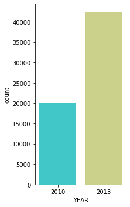

```python
sns.catplot(x="YEAR",
               data=allnewdatanow, kind="count", palette='rainbow',
               height=5, aspect=0.6)
```

# RACE, GENDER, DEGREE

```python
allnewdatanow.pivot_table(index=['GENDER','RACE'], values=['REFID'], aggfunc='count')
```

| GENDER | RACE | REFID |
| --- | --- | --- |
| Female | Asian | 4358 |
|  | Under-represented minorities | 7552 |
|  | White | 15414 |
| Male | Asian | 6420 |
|  | Under-represented minorities | 6826 |
|  | White | 21803 |

```python
allnewdatanow.pivot_table(index=['GENDER','RECENT_DEGREE'], values=['REFID'], aggfunc='count')
```

| GENDER | RECENT_DEGREE | REFID |
| --- | --- | --- |
| Female | Bachelor | 13777 |
|  | Doctorate | 791 |
|  | Master | 11064 |
|  | No Degree | 457 |
|  | Professional | 1235 |
| Male | Bachelor | 19564 |
|  | Doctorate | 1174 |
|  | Master | 11664 |
|  | No Degree | 972 |
|  | Professional | 1675 |

```python
allnewdatanow.pivot_table(index=['RACE','RECENT_DEGREE'], values=['REFID'], aggfunc='count')
```

| RACE | RECENT_DEGREE | REFID |
| --- | --- | --- |
| Asian | Bachelor | 4720 |
|  | Doctorate | 524 |
|  | Master | 4362 |
|  | No Degree | 683 |
|  | Professional | 489 |
| Under-represented minorities | Bachelor | 8358 |
|  | Doctorate | 324 |
|  | Master | 4863 |
|  | No Degree | 231 |
|  | Professional | 602 |
| White | Bachelor | 20263 |
|  | Doctorate | 1117 |
|  | Master | 13503 |
|  | No Degree | 515 |
|  | Professional | 1819 |

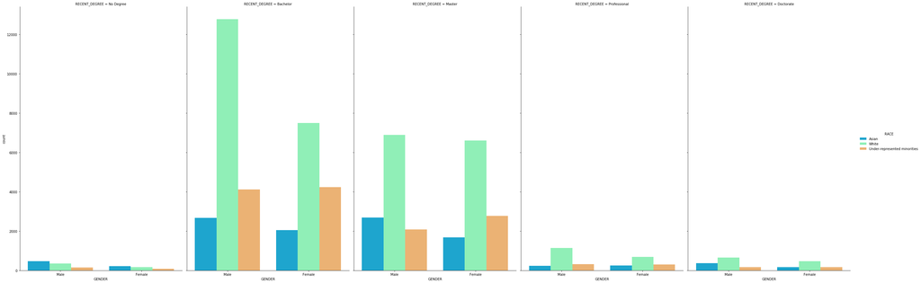

```python
sns.catplot(x="GENDER", hue="RACE", col="RECENT_DEGREE",
               data=allnewdatanow, kind="count", palette='rainbow',
               height=12, aspect=0.6)
```

# CITIZENSHIP

```python
allnewdatanow.pivot_table(index=['US_CITIZEN_TYPE'], values=['REFID'], aggfunc='count')
```

| US_CITIZEN_TYPE | REFID |
| --- | --- |
| Born abroad of American parents | 891 |
| Born in US or US territories | 46325 |
| By naturalization | 7988 |
| None | 7169 |

```python
allnewdatanow.pivot_table(index=['US_CITIZENSHIP','GENDER','RACE'], values=['REFID'], aggfunc='count')
```

| US_CITIZENSHIP | GENDER | RACE | REFID |
| --- | --- | --- | --- |
| No | Female | Asian | 1470 |
|  |  | Under-represented minorities | 423 |
|  |  | White | 620 |
|  | Male | Asian | 2656 |
|  |  | Under-represented minorities | 776 |
|  |  | White | 1224 |
| Yes | Female | Asian | 2888 |
|  |  | Under-represented minorities | 7129 |
|  |  | White | 14794 |
|  | Male | Asian | 3764 |
|  |  | Under-represented minorities | 6050 |
|  |  | White | 20579 |

```python
allnewdatanow.pivot_table(index=['US_CITIZEN_TYPE','TOTAL_CHILDREN'], values=['REFID'], aggfunc='count')
```

| US_CITIZEN_TYPE | TOTAL_CHILDREN | REFID |
| --- | --- | --- |
| Born abroad of American parents | None | 512 |
|  | One child | 157 |
|  | Two or more children | 222 |
| Born in US or US territories | None | 27843 |
|  | One child | 7656 |
|  | Two or more children | 10826 |
| By naturalization | None | 3891 |
|  | One child | 1580 |
|  | Two or more children | 2517 |
| None | None | 4301 |
|  | One child | 1441 |
|  | Two or more children | 1427 |

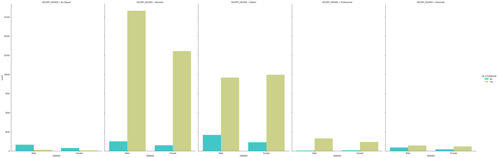

```python
sns.catplot(x="GENDER", hue="US_CITIZENSHIP", col="RECENT_DEGREE",
               data=allnewdatanow, kind="count", palette='rainbow',
               height=12, aspect=0.6)
```

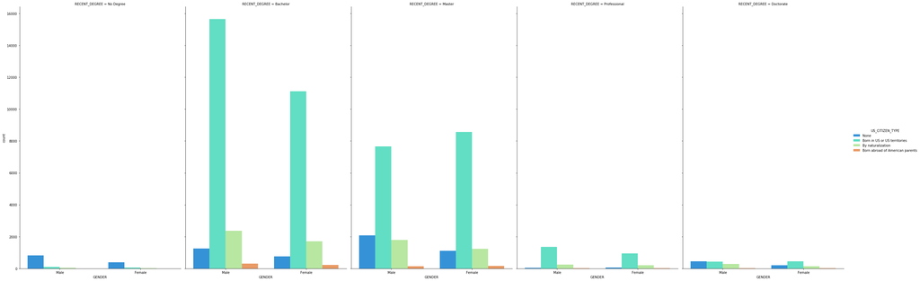

```python
sns.catplot(x="GENDER", hue="US_CITIZEN_TYPE", col="RECENT_DEGREE",
               data=allnewdatanow, kind="count", palette='rainbow',
               height=12, aspect=0.6)
```

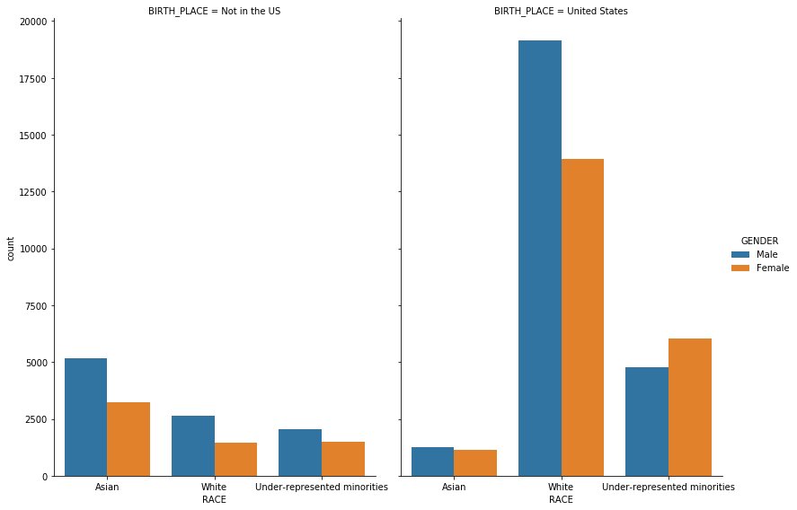

```python
sns.catplot(x="RACE", hue="GENDER", col="BIRTH_PLACE",
               data=allnewdatanow, kind="count",
               height=8, aspect=.7)
```

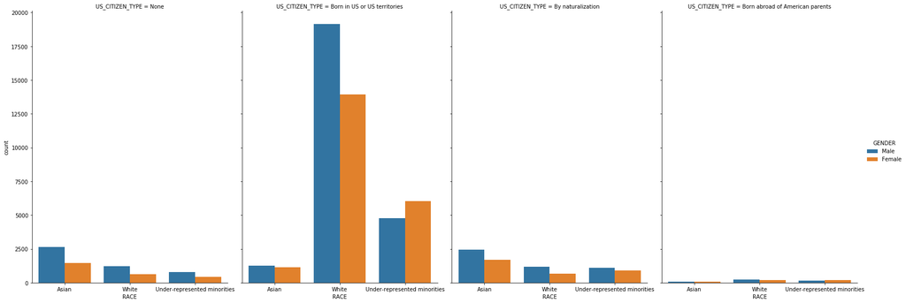

```python
sns.catplot(x="RACE", hue="GENDER", col="US_CITIZEN_TYPE",
               data=allnewdatanow, kind="count",
               height=8, aspect=.7)
```

# SALARY AND AGE

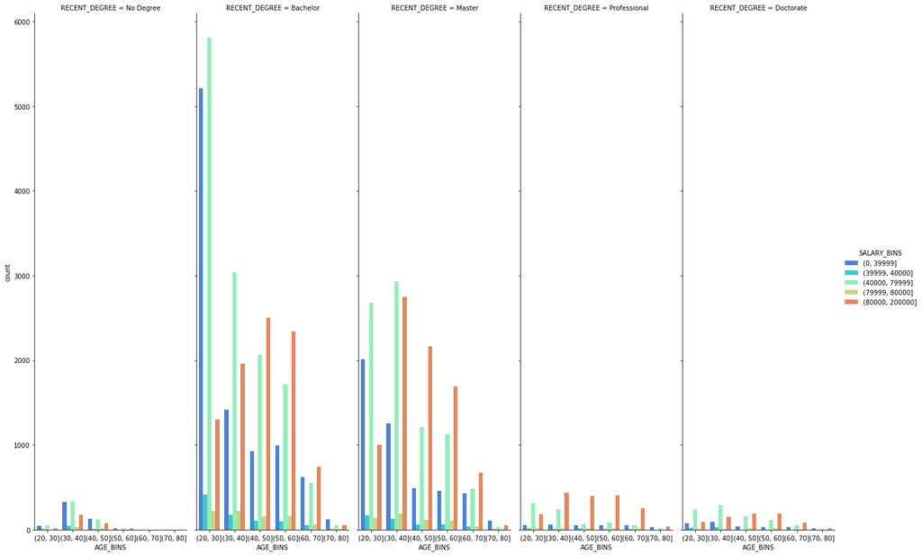

```python
sns.catplot(x="AGE_BINS", hue="SALARY_BINS", col="RECENT_DEGREE",
               data=allnewdatanow, kind="count", palette='rainbow',
               height=12, aspect=.3)
```

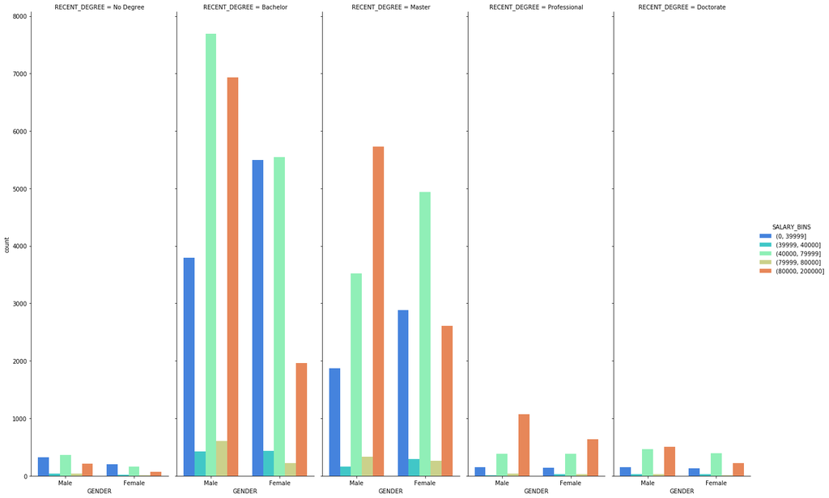

```python
sns.catplot(x="GENDER", hue="SALARY_BINS", col="RECENT_DEGREE",
               data=allnewdatanow, kind="count", palette='rainbow',
               height=12, aspect=.3)
```

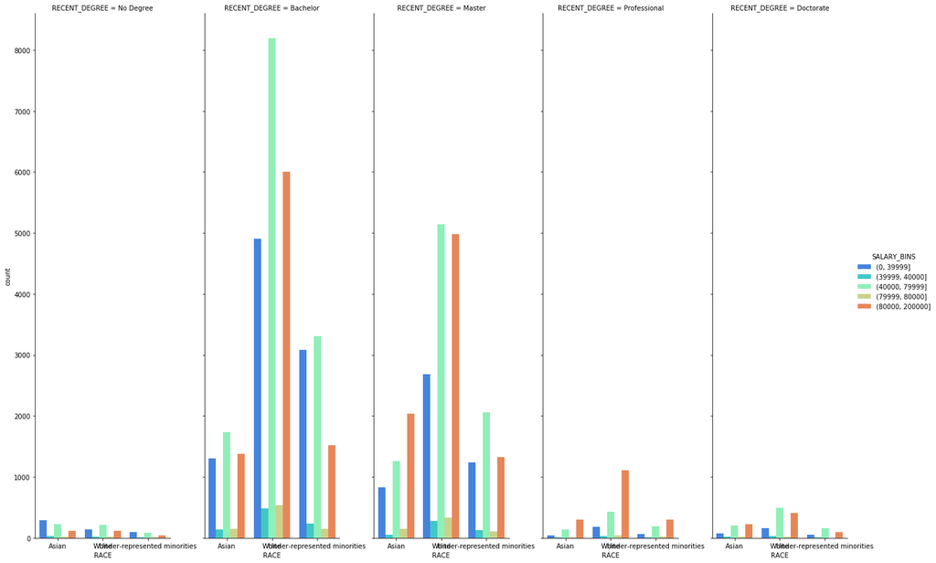

```python
sns.catplot(x="RACE", hue="SALARY_BINS", col="RECENT_DEGREE",
               data=allnewdatanow, kind="count", palette='rainbow',
               height=12, aspect=.3)
```

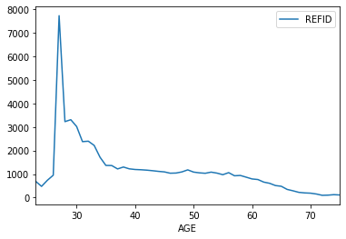

```python
allnewdatanow.pivot_table(index=['AGE'], values=['REFID'], aggfunc='count').plot()
```

# EMPLOYMENT

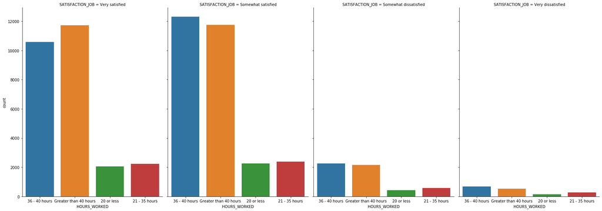

```python
sns.catplot(x="HOURS_WORKED",  col="SATISFACTION_JOB",
               data=allnewdatanow, kind="count",
               height=8, aspect=.7)
```

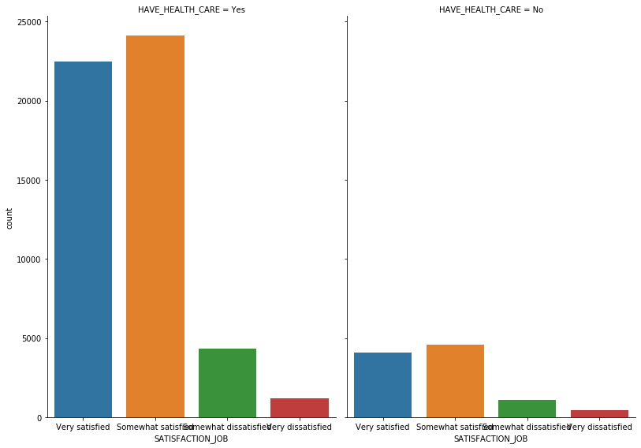

```python
sns.catplot(x="SATISFACTION_JOB", col="HAVE_HEALTH_CARE",
               data=allnewdatanow, kind="count",
               height=8, aspect=.7)
```

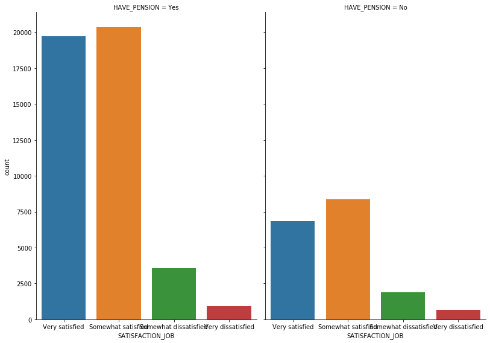

```python
sns.catplot(x="SATISFACTION_JOB", col="HAVE_PENSION",
               data=allnewdatanow, kind="count",
               height=8, aspect=.7)
```

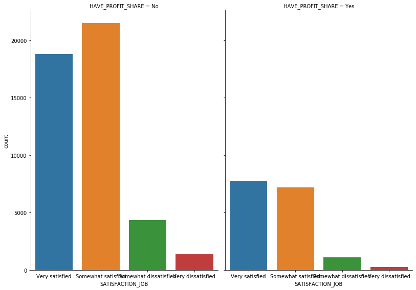

```python
sns.catplot(x="SATISFACTION_JOB", col="HAVE_PROFIT_SHARE",
               data=allnewdatanow, kind="count",
               height=8, aspect=.7)
```

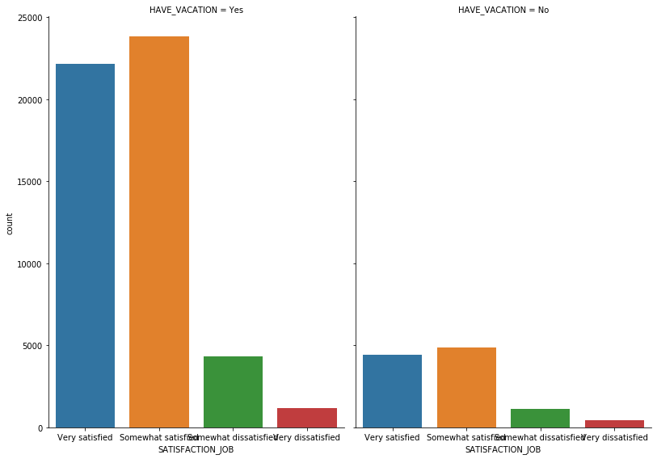

```python
sns.catplot(x="SATISFACTION_JOB", col="HAVE_VACATION",
               data=allnewdatanow, kind="count",
               height=8, aspect=.7)
```

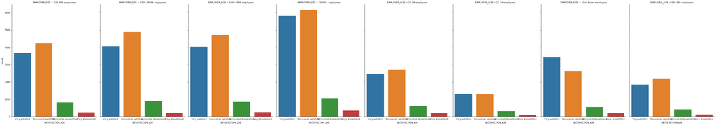

```python
sns.catplot(x="SATISFACTION_JOB", col="EMPLOYER_SIZE",
               data=allnewdatanow, kind="count",
               height=8, aspect=.7)
```

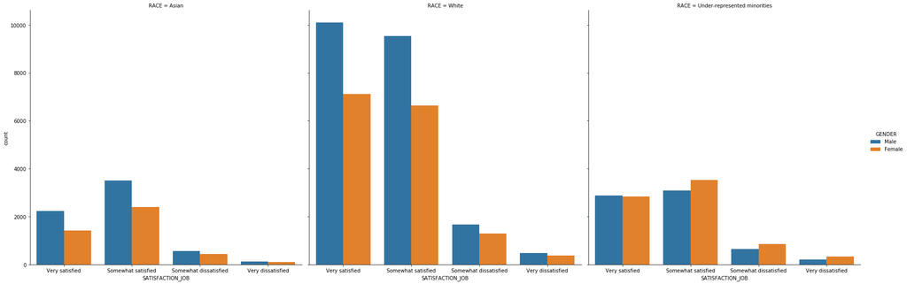

```python
sns.catplot(x="SATISFACTION_JOB",  col= "RACE", hue = "GENDER",
               data=allnewdatanow, kind="count",
               height=8, aspect=1)
```

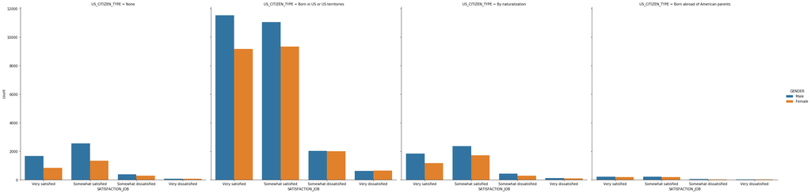

```python
sns.catplot(x="SATISFACTION_JOB",  col= "US_CITIZEN_TYPE", hue = "GENDER",
               data=allnewdatanow, kind="count",
               height=8, aspect=1)
```

# DEGREE AND EDUCATION

```python
reasonnow = allnewdatanow.pivot_table(index=['REASON_EDUCATION_ADVANCE_OPPORTUNITIES','REASON_EDUCATION_BEFORE_CAREER','REASON_EDUCATION_CHANGE_CAREER','REASON_EDUCATION_PERSONAL'], values=['REFID'], aggfunc='count')
```

```python
reasonnow.transpose()
```

| REASON_EDUCATION_ADVANCE_OPPORTUNITIES REASON_EDUCATION_BEFORE_CAREER REASON_EDUCATION_CHANGE_CAREER REASON_EDUCATION_PERSONAL | No | No Yes | No Yes | No Yes | No Yes | No Yes | No Yes | No Yes | Yes No | Yes No | Yes No | Yes No | Yes No | Yes No | Yes No | Yes |
| --- | --- | --- | --- | --- | --- | --- | --- | --- | --- | --- | --- | --- | --- | --- | --- | --- |
| REFID | 55800 | 303 | 119 | 49 | 569 | 212 | 184 | 124 | 883 | 631 | 229 | 197 | 1048 | 867 | 584 | 574 |

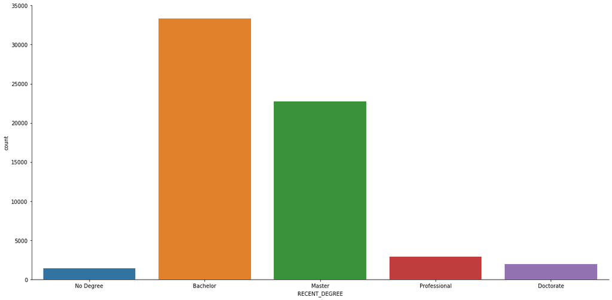

```python
sns.catplot(x="RECENT_DEGREE",
               data=allnewdatanow, kind="count",
               height=8, aspect=2)
```

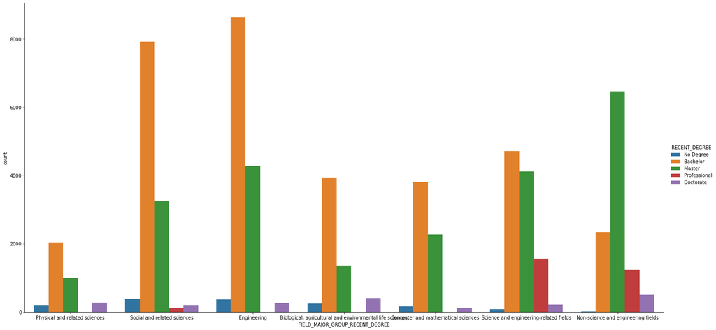

```python
sns.catplot(x="FIELD_MAJOR_GROUP_RECENT_DEGREE", hue="RECENT_DEGREE",
               data=allnewdatanow, kind="count",
               height=10, aspect=2)
```

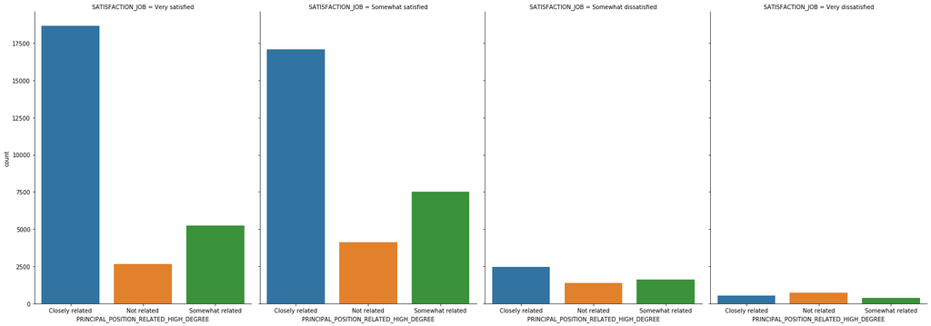

```python
sns.catplot(x="PRINCIPAL_POSITION_RELATED_HIGH_DEGREE", col="SATISFACTION_JOB",
               data=allnewdatanow, kind="count",
               height=8, aspect=.7)
```

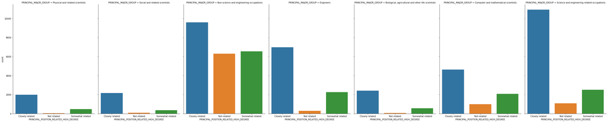

```python
sns.catplot(x="PRINCIPAL_POSITION_RELATED_HIGH_DEGREE", col="PRINCIPAL_MAJOR_GROUP",
               data=allnewdatanow, kind="count",
               height=8, aspect=.7)
```

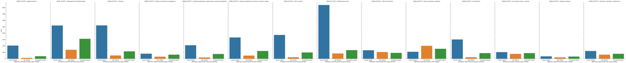

```python
sns.catplot(x="PRINCIPAL_POSITION_RELATED_HIGH_DEGREE", col="WORK_ACTIVITY",
               data=allnewdatanow, kind="count",
               height=8, aspect=.7)
```

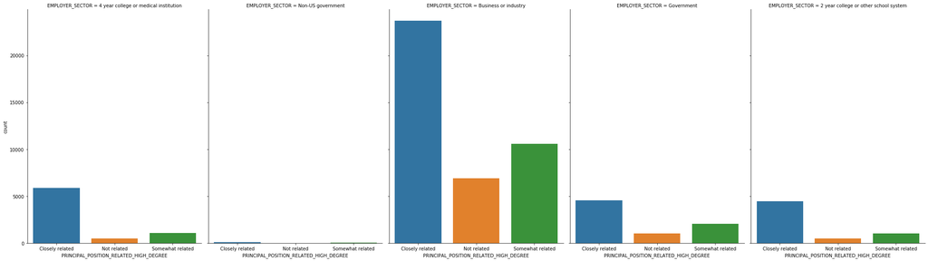

```python
sns.catplot(x="PRINCIPAL_POSITION_RELATED_HIGH_DEGREE", col="EMPLOYER_SECTOR",
               data=allnewdatanow, kind="count",
               height=8, aspect=.7)
```

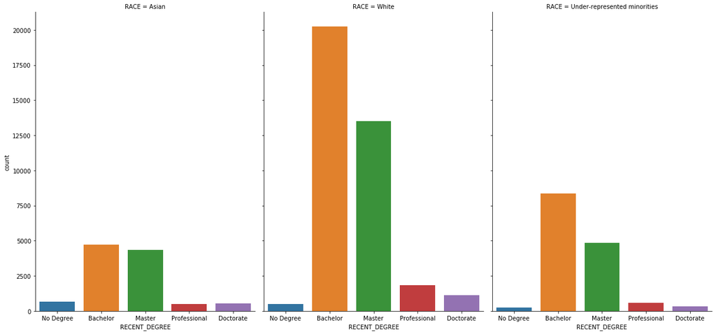

```python
sns.catplot(x="RECENT_DEGREE", col="RACE",
               data=allnewdatanow, kind="count",
               height=8, aspect=.7)
```

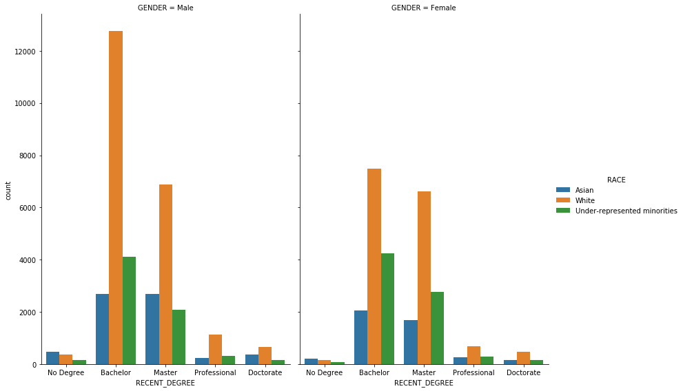

```python
sns.catplot(x="RECENT_DEGREE", col="GENDER", hue = "RACE",
               data=allnewdatanow, kind="count",
               height=8, aspect=.7)
```

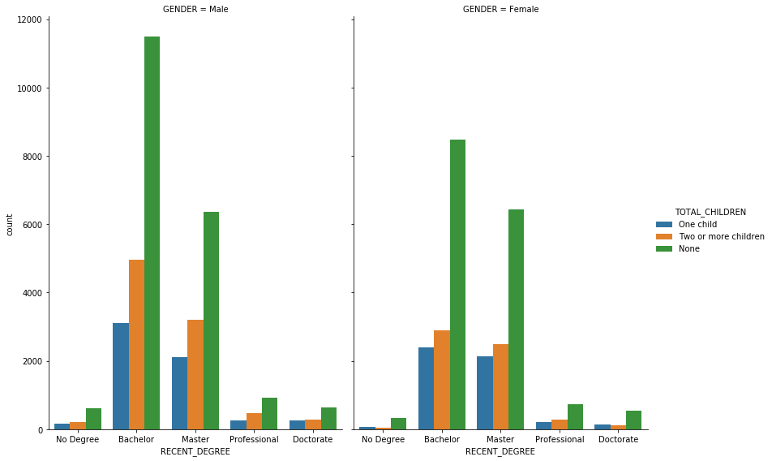

```python
sns.catplot(x="RECENT_DEGREE", col="GENDER", hue = "TOTAL_CHILDREN",
               data=allnewdatanow, kind="count",
               height=8, aspect=.7)
```

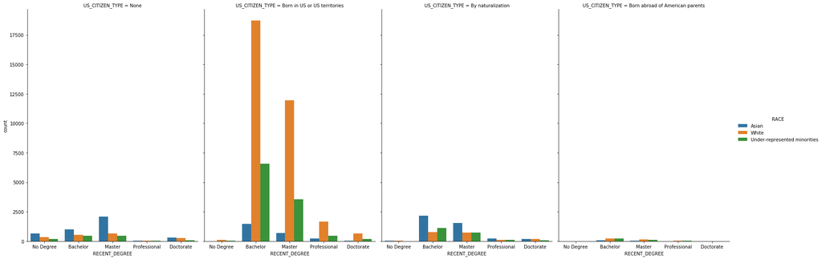

```python
sns.catplot(x="RECENT_DEGREE", col="US_CITIZEN_TYPE", hue = "RACE",
               data=allnewdatanow, kind="count",
               height=8, aspect=.7)
```

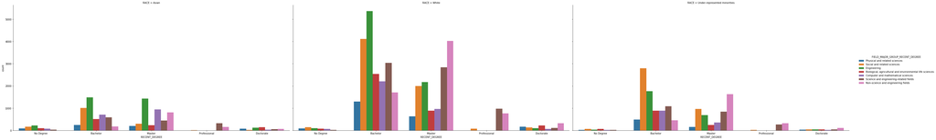

```python
sns.catplot(x="RECENT_DEGREE", col = "RACE", hue = "FIELD_MAJOR_GROUP_RECENT_DEGREE",
               data=allnewdatanow, kind="count",
               height=8, aspect=2)
```

```python
allnewdatanowvd_vs = allnewdatanow[allnewdatanow.SATISFACTION_JOB.isin(["Very satisfied","Very dissatisfied"])]
```

```python
allnewdatanowvd_vs
```

|  | REFID | YEAR | AGE | GENDER | RACE | BIRTH_PLACE | US_CITIZENSHIP | US_CITIZEN_TYPE | TOTAL_CHILDREN | FIELD_MAJOR_GROUP_BACHELOR_DEGREE | HIGHEST_DEGREE | FIELD_MAJOR_HIGHEST_DEGREE | FIELD_MAJOR_GROUP_HIGHEST_DEGREE | RECENT_DEGREE | FIELD_MAJOR_RECENT_DEGREE | FIELD_MAJOR_GROUP_RECENT_DEGREE | REASON_EDUCATION_ADVANCE_OPPORTUNITIES | REASON_EDUCATION_BEFORE_CAREER | REASON_EDUCATION_CHANGE_CAREER | REASON_EDUCATION_PERSONAL | REASON_EDUCATION_CERIFICATION | REASON_EDUCATION_BY_EMPLOYER | REASON_EDUCATION_ADVANCE_SKILL_IN_FIELD | REASON_EDUCATION_PAID_BY_EMPLOYER | HOURS_WORKED | WEEKS_WORKED | HAVE_HEALTH_CARE | HAVE_PENSION | HAVE_PROFIT_SHARE | … |
| --- | --- | --- | --- | --- | --- | --- | --- | --- | --- | --- | --- | --- | --- | --- | --- | --- | --- | --- | --- | --- | --- | --- | --- | --- | --- | --- | --- | --- | --- | --- |
| 0 | 20901QY86 | 2010 | 37 | Male | Asian | Not in the US | No | None | One child | Physical and related sciences | Doctorate | Physics and astronomy | Physical and related sciences | No Degree | Physics and astronomy | Physical and related sciences | No | No | No | No | No | No | No | No | 36 - 40 hours | 40-52 weeks | Yes | Yes | No | … |
| 1 | 20902AN23 | 2013 | 44 | Male | White | Not in the US | No | None | Two or more children | Physical and related sciences | Doctorate | Other physical and related sciences | Physical and related sciences | No Degree | NaN | Physical and related sciences | No | No | No | No | No | No | No | No | Greater than 40 hours | 40-52 weeks | Yes | Yes | No | … |
| 4 | 20902TH37 | 2013 | 45 | Male | Under-represented minorities | Not in the US | No | None | None | Engineering | Doctorate | Economics | Social and related sciences | No Degree | Economics | Social and related sciences | No | No | No | No | No | No | No | No | Greater than 40 hours | 40-52 weeks | No | No | No | … |
| 5 | 20902VN70 | 2010 | 42 | Male | White | Not in the US | No | None | None | Engineering | Doctorate | Other engineering | Engineering | No Degree | Other engineering | Engineering | No | No | No | No | Yes | Yes | Yes | Yes | Greater than 40 hours | 40-52 weeks | Yes | Yes | No | … |
| 12 | 20905FT59 | 2010 | 46 | Female | White | United States | Yes | Born in US or US territories | Two or more children | Biological, agricultural and environmental lif... | Doctorate | Sociology and anthropology | Social and related sciences | No Degree | Sociology and anthropology | Social and related sciences | No | No | No | No | No | No | No | No | 20 or less | 40-52 weeks | No | No | No | … |
| 13 | 20905FW07 | 2013 | 44 | Female | White | Not in the US | Yes | By naturalization | None | Engineering | Doctorate | Computer and mathematical science | Computer and mathematical sciences | No Degree | Computer and mathematical science | Computer and mathematical sciences | No | No | No | No | No | No | No | No | Greater than 40 hours | 40-52 weeks | Yes | Yes | No | … |
| 14 | 20905GV97 | 2010 | 37 | Female | Asian | Not in the US | Yes | By naturalization | Two or more children | Biological, agricultural and environmental lif... | Doctorate | Biological sciences | Biological, agricultural and environmental lif... | No Degree | Biological sciences | Biological, agricultural and environmental lif... | No | No | No | No | No | No | No | No | 20 or less | 40-52 weeks | No | No | No | … |
| 17 | 20906JP76 | 2010 | 44 | Male | Asian | Not in the US | Yes | By naturalization | None | Physical and related sciences | Doctorate | Biological sciences | Biological, agricultural and environmental lif... | No Degree | Biological sciences | Biological, agricultural and environmental lif... | No | No | No | No | No | No | No | No | Greater than 40 hours | 40-52 weeks | Yes | Yes | No | … |
| 18 | 20906KW09 | 2010 | 37 | Male | Asian | Not in the US | No | None | None | Engineering | Doctorate | Chemical engineering | Engineering | No Degree | Chemical engineering | Engineering | No | No | No | No | No | No | No | No | Greater than 40 hours | 40-52 weeks | Yes | Yes | No | … |
| 25 | 20908AM20 | 2013 | 44 | Male | Under-represented minorities | Not in the US | Yes | By naturalization | None | Social and related sciences | Doctorate | Economics | Social and related sciences | No Degree | Economics | Social and related sciences | No | No | No | No | No | No | No | No | 36 - 40 hours | 40-52 weeks | Yes | Yes | No | … |
| 26 | 20908WM44 | 2013 | 42 | Female | White | United States | Yes | Born in US or US territories | Two or more children | Non-science and engineering fields | Doctorate | Chemical engineering | Engineering | No Degree | Chemical engineering | Engineering | No | No | No | No | No | No | No | No | 21 - 35 hours | 40-52 weeks | No | Yes | No | … |
| 31 | 20910EH54 | 2013 | 39 | Female | White | Not in the US | No | None | None | Engineering | Doctorate | Chemical engineering | Engineering | No Degree | Chemical engineering | Engineering | No | No | No | No | No | No | No | No | Greater than 40 hours | 40-52 weeks | Yes | Yes | Yes | … |
| 33 | 20911EM23 | 2010 | 44 | Male | Asian | Not in the US | No | None | None | Physical and related sciences | Doctorate | Physics and astronomy | Physical and related sciences | No Degree | Physics and astronomy | Physical and related sciences | No | No | No | No | No | No | No | No | 21 - 35 hours | 40-52 weeks | Yes | Yes | No | … |
| 35 | 20911JY29 | 2010 | 43 | Female | Under-represented minorities | Not in the US | No | None | One child | Science and engineering-related fields | Doctorate | Psychology | Social and related sciences | No Degree | Psychology | Social and related sciences | No | No | No | No | No | No | No | No | 21 - 35 hours | 40-52 weeks | Yes | Yes | Yes | … |
| 37 | 20911VW83 | 2010 | 38 | Male | White | Not in the US | Yes | By naturalization | One child | Engineering | Doctorate | Electrical, electronics and communications eng... | Engineering | No Degree | Electrical, electronics and communications eng... | Engineering | No | No | No | No | No | No | No | No | 36 - 40 hours | 40-52 weeks | Yes | Yes | No | … |
| 39 | 20912AT50 | 2010 | 41 | Female | Under-represented minorities | United States | Yes | Born in US or US territories | None | Biological, agricultural and environmental lif... | Doctorate | Biological sciences | Biological, agricultural and environmental lif... | No Degree | Biological sciences | Biological, agricultural and environmental lif... | No | No | No | No | No | No | No | No | Greater than 40 hours | 40-52 weeks | Yes | Yes | Yes | … |
| 40 | 20912KP43 | 2010 | 37 | Male | White | United States | Yes | Born in US or US territories | None | Physical and related sciences | Doctorate | Physics and astronomy | Physical and related sciences | No Degree | Physics and astronomy | Physical and related sciences | No | No | No | No | No | No | No | No | Greater than 40 hours | 40-52 weeks | Yes | Yes | Yes | … |
| 42 | 20912WX02 | 2013 | 45 | Male | Under-represented minorities | Not in the US | Yes | By naturalization | Two or more children | Engineering | Doctorate | Civil engineering | Engineering | No Degree | Civil engineering | Engineering | No | No | No | No | No | No | No | No | 36 - 40 hours | 40-52 weeks | Yes | No | No | … |
| 48 | 20914RR46 | 2010 | 38 | Male | White | United States | Yes | Born in US or US territories | Two or more children | Social and related sciences | Doctorate | Sociology and anthropology | Social and related sciences | No Degree | Sociology and anthropology | Social and related sciences | No | No | No | No | No | No | No | No | Greater than 40 hours | 40-52 weeks | No | Yes | No | … |
| 49 | 20915GT87 | 2010 | 37 | Male | Asian | Not in the US | No | None | One child | Engineering | Doctorate | Economics | Social and related sciences | No Degree | Economics | Social and related sciences | No | No | No | No | No | No | No | No | 36 - 40 hours | 40-52 weeks | Yes | Yes | No | … |
| 50 | 20915MP88 | 2010 | 43 | Male | Under-represented minorities | Not in the US | No | None | None | NaN | Doctorate | Electrical, electronics and communications eng... | Engineering | No Degree | Electrical, electronics and communications eng... | Engineering | No | No | No | No | No | No | No | No | Greater than 40 hours | 40-52 weeks | Yes | Yes | No | … |
| 52 | 20915TW98 | 2010 | 36 | Male | Under-represented minorities | Not in the US | No | None | None | Social and related sciences | Doctorate | Economics | Social and related sciences | No Degree | Economics | Social and related sciences | No | No | No | No | No | No | No | No | Greater than 40 hours | 40-52 weeks | Yes | Yes | No | … |
| 59 | 20918FG54 | 2010 | 38 | Male | Asian | Not in the US | No | None | One child | Engineering | Doctorate | Mechanical engineering | Engineering | No Degree | Mechanical engineering | Engineering | No | No | No | No | No | No | No | No | Greater than 40 hours | 40-52 weeks | Yes | Yes | No | … |
| 61 | 20924FX26 | 2013 | 40 | Male | Under-represented minorities | United States | Yes | Born in US or US territories | None | Computer and mathematical sciences | Doctorate | Computer and mathematical science | Computer and mathematical sciences | No Degree | Computer and mathematical science | Computer and mathematical sciences | No | No | No | No | No | No | No | No | 36 - 40 hours | 40-52 weeks | No | Yes | No | … |
| 64 | 20924HM96 | 2010 | 41 | Male | White | Not in the US | Yes | By naturalization | None | Computer and mathematical sciences | Doctorate | Computer and mathematical science | Computer and mathematical sciences | No Degree | Computer and mathematical science | Computer and mathematical sciences | No | No | No | No | No | No | No | No | 36 - 40 hours | 1-10 weeks | Yes | No | No | … |
| 66 | 20924JA24 | 2010 | 37 | Female | White | Not in the US | No | None | None | Science and engineering-related fields | Doctorate | Other biological, agricultural, environmental ... | Biological, agricultural and environmental lif... | No Degree | Other biological, agricultural, environmental ... | Biological, agricultural and environmental lif... | No | No | No | No | No | No | No | No | 36 - 40 hours | 40-52 weeks | No | Yes | No | … |
| 67 | 20924NW08 | 2013 | 44 | Male | White | Not in the US | No | None | Two or more children | Physical and related sciences | Doctorate | Other physical and related sciences | Physical and related sciences | No Degree | NaN | Physical and related sciences | No | No | No | No | No | No | No | No | Greater than 40 hours | 40-52 weeks | Yes | Yes | No | … |
| 69 | 20924YE93 | 2010 | 40 | Male | Asian | Not in the US | No | None | Two or more children | Engineering | Doctorate | Other engineering | Engineering | No Degree | Other engineering | Engineering | No | No | No | No | No | No | No | No | 36 - 40 hours | 40-52 weeks | Yes | Yes | No | … |
| 71 | 20925QT37 | 2013 | 52 | Male | White | Not in the US | No | None | None | Social and related sciences | Doctorate | Political and related sciences | Social and related sciences | No Degree | Political and related sciences | Social and related sciences | No | No | No | No | No | No | No | No | 36 - 40 hours | 40-52 weeks | Yes | Yes | No | … |
| 78 | 20926QQ73 | 2013 | 41 | Male | White | Not in the US | No | None | None | Engineering | Doctorate | Other engineering | Engineering | No Degree | Other engineering | Engineering | No | No | No | No | No | No | No | No | Greater than 40 hours | 40-52 weeks | No | Yes | No | … |
| ... | ... | ... | ... | ... | ... | ... | ... | ... | ... | ... | ... | ... | ... | ... | ... | ... | ... | ... | ... | ... | ... | ... | ... | ... | ... | ... | ... | ... | ... | … |
| 73219 | 996152823 | 2010 | 55 | Female | Under-represented minorities | United States | Yes | Born in US or US territories | None | Science and engineering-related fields | Master | Management and administration | Non-science and engineering fields | Master | Management and administration | Non-science and engineering fields | No | No | No | No | No | No | No | No | Greater than 40 hours | 40-52 weeks | Yes | Yes | Yes | … |
| 73221 | 996197383 | 2010 | 30 | Female | White | United States | Yes | Born in US or US territories | None | Social and related sciences | Master | Other non-science and engineering | Non-science and engineering fields | Master | Other non-science and engineering | Non-science and engineering fields | No | No | No | No | No | No | No | No | 36 - 40 hours | 40-52 weeks | Yes | Yes | Yes | … |
| 73224 | 996342066 | 2010 | 32 | Female | Under-represented minorities | United States | Yes | Born in US or US territories | Two or more children | Engineering | Master | Management and administration | Non-science and engineering fields | Master | Management and administration | Non-science and engineering fields | No | No | No | No | No | No | No | No | 36 - 40 hours | 40-52 weeks | Yes | Yes | No | … |
| 73225 | 996382246 | 2010 | 34 | Male | Asian | Not in the US | No | None | None | Engineering | Master | Management and administration | Non-science and engineering fields | Master | Management and administration | Non-science and engineering fields | No | No | No | No | No | No | No | No | Greater than 40 hours | 40-52 weeks | Yes | Yes | Yes | … |
| 73228 | 996436899 | 2010 | 32 | Male | White | United States | Yes | Born in US or US territories | One child | Biological, agricultural and environmental lif... | Bachelor | Biological sciences | Biological, agricultural and environmental lif... | Bachelor | Biological sciences | Biological, agricultural and environmental lif... | Yes | No | No | No | No | No | No | No | 36 - 40 hours | 40-52 weeks | Yes | Yes | No | … |
| 73229 | 996474527 | 2010 | 34 | Male | Asian | United States | Yes | Born in US or US territories | None | Social and related sciences | Master | Political and related sciences | Social and related sciences | Master | Political and related sciences | Social and related sciences | No | No | No | No | No | No | No | No | 36 - 40 hours | 40-52 weeks | Yes | Yes | No | … |
| 73230 | 996484392 | 2010 | 33 | Male | Under-represented minorities | United States | Yes | Born in US or US territories | Two or more children | Engineering | Bachelor | Civil engineering | Engineering | Bachelor | Civil engineering | Engineering | Yes | No | Yes | No | No | Yes | No | Yes | Greater than 40 hours | 40-52 weeks | Yes | Yes | No | … |
| 73237 | 996839247 | 2010 | 46 | Male | White | United States | Yes | Born in US or US territories | Two or more children | Engineering | Bachelor | Mechanical engineering | Engineering | Bachelor | Mechanical engineering | Engineering | No | No | No | No | No | No | No | No | 36 - 40 hours | 40-52 weeks | Yes | Yes | Yes | … |
| 73239 | 997142713 | 2010 | 48 | Male | White | United States | Yes | Born in US or US territories | None | Engineering | Bachelor | Mechanical engineering | Engineering | Bachelor | Mechanical engineering | Engineering | No | No | No | No | No | No | No | No | Greater than 40 hours | 40-52 weeks | Yes | Yes | Yes | … |
| 73241 | 997306570 | 2010 | 32 | Male | Under-represented minorities | United States | Yes | Born in US or US territories | Two or more children | Computer and mathematical sciences | Master | Computer and mathematical science | Computer and mathematical sciences | Master | Computer and mathematical science | Computer and mathematical sciences | No | No | No | No | No | No | No | No | Greater than 40 hours | 40-52 weeks | Yes | Yes | Yes | … |
| 73248 | 997569372 | 2010 | 45 | Male | White | United States | Yes | Born in US or US territories | Two or more children | Computer and mathematical sciences | Master | Other engineering | Engineering | Master | Other engineering | Engineering | No | No | No | No | No | No | No | No | 36 - 40 hours | 40-52 weeks | Yes | Yes | No | … |
| 73250 | 997755215 | 2010 | 32 | Female | Under-represented minorities | Not in the US | No | None | None | Engineering | Master | Mechanical engineering | Engineering | Master | Mechanical engineering | Engineering | No | No | No | No | No | No | No | No | 36 - 40 hours | 40-52 weeks | Yes | Yes | Yes | … |
| 73253 | 997913836 | 2010 | 57 | Male | White | United States | Yes | Born in US or US territories | None | Biological, agricultural and environmental lif... | Bachelor | Biological sciences | Biological, agricultural and environmental lif... | Bachelor | Biological sciences | Biological, agricultural and environmental lif... | No | No | No | No | No | No | No | No | Greater than 40 hours | 40-52 weeks | No | No | No | … |
| 73254 | 997923261 | 2010 | 33 | Male | Asian | United States | Yes | Born in US or US territories | One child | Engineering | Master | Electrical, electronics and communications eng... | Engineering | Master | Electrical, electronics and communications eng... | Engineering | No | No | No | No | No | No | No | No | Greater than 40 hours | 40-52 weeks | Yes | Yes | Yes | … |
| 73255 | 997948617 | 2010 | 31 | Male | Under-represented minorities | United States | Yes | Born in US or US territories | None | Social and related sciences | Bachelor | Economics | Social and related sciences | Bachelor | Economics | Social and related sciences | No | No | No | No | No | No | No | No | 21 - 35 hours | 40-52 weeks | No | No | No | … |
| 73256 | 997993558 | 2010 | 31 | Female | White | United States | Yes | Born in US or US territories | One child | Social and related sciences | Bachelor | Sociology and anthropology | Social and related sciences | Bachelor | Sociology and anthropology | Social and related sciences | No | No | No | No | No | No | No | No | 21 - 35 hours | 40-52 weeks | Yes | No | No | … |
| 73262 | 998459283 | 2010 | 36 | Male | White | United States | Yes | Born in US or US territories | None | Non-science and engineering fields | Master | Health-related fields | Science and engineering-related fields | Master | Health-related fields | Science and engineering-related fields | No | No | No | No | No | No | No | No | 21 - 35 hours | 40-52 weeks | Yes | Yes | No | … |
| 73265 | 998622179 | 2010 | 36 | Male | White | United States | Yes | Born in US or US territories | Two or more children | Physical and related sciences | Master | Other science and engineering-related | Science and engineering-related fields | Master | Other science and engineering-related | Science and engineering-related fields | Yes | No | No | No | No | No | No | No | Greater than 40 hours | 40-52 weeks | Yes | Yes | No | … |
| 73266 | 998672671 | 2010 | 34 | Male | Under-represented minorities | Not in the US | Yes | By naturalization | Two or more children | Engineering | Master | Management and administration | Non-science and engineering fields | Master | Management and administration | Non-science and engineering fields | Yes | No | No | Yes | No | Yes | Yes | No | Greater than 40 hours | 40-52 weeks | No | No | No | … |
| 73267 | 998730068 | 2010 | 43 | Male | White | United States | Yes | Born in US or US territories | Two or more children | Engineering | Master | Other engineering | Engineering | Master | Other engineering | Engineering | No | No | No | No | No | No | No | No | Greater than 40 hours | 40-52 weeks | Yes | No | No | … |
| 73269 | 998883953 | 2010 | 32 | Female | Under-represented minorities | United States | Yes | Born in US or US territories | Two or more children | Social and related sciences | Master | Other non-science and engineering | Non-science and engineering fields | Master | Other non-science and engineering | Non-science and engineering fields | No | No | No | No | No | No | No | No | 21 - 35 hours | 40-52 weeks | Yes | Yes | No | … |
| 73271 | 999189159 | 2010 | 55 | Male | White | United States | Yes | Born in US or US territories | None | Physical and related sciences | Master | Other physical and related sciences | Physical and related sciences | Master | NaN | Physical and related sciences | No | No | No | No | No | No | No | No | Greater than 40 hours | 40-52 weeks | Yes | Yes | No | … |
| 73273 | 999214872 | 2010 | 38 | Female | Under-represented minorities | United States | Yes | Born in US or US territories | Two or more children | Social and related sciences | Bachelor | Psychology | Social and related sciences | Bachelor | Psychology | Social and related sciences | No | No | No | No | No | No | No | No | 21 - 35 hours | 40-52 weeks | Yes | Yes | No | … |
| 73274 | 999225747 | 2010 | 39 | Female | Asian | Not in the US | Yes | By naturalization | Two or more children | Non-science and engineering fields | Master | Other engineering | Engineering | Master | Other engineering | Engineering | No | No | No | No | No | No | No | No | 36 - 40 hours | 40-52 weeks | Yes | Yes | Yes | … |
| 73275 | 999265997 | 2010 | 31 | Female | White | United States | Yes | Born in US or US territories | One child | Social and related sciences | Bachelor | Sociology and anthropology | Social and related sciences | Bachelor | Sociology and anthropology | Social and related sciences | No | No | No | No | No | No | No | No | 36 - 40 hours | 40-52 weeks | Yes | Yes | Yes | … |
| 73276 | 999331825 | 2010 | 31 | Male | White | United States | Yes | Born in US or US territories | None | Physical and related sciences | Master | Economics | Social and related sciences | Master | Economics | Social and related sciences | No | No | No | No | No | No | No | No | Greater than 40 hours | 40-52 weeks | Yes | No | No | … |
| 73283 | 999700871 | 2010 | 51 | Male | Under-represented minorities | Not in the US | Yes | By naturalization | Two or more children | Physical and related sciences | Master | Chemistry, except biochemistry | Physical and related sciences | Master | Chemistry, except biochemistry | Physical and related sciences | No | No | No | No | No | No | No | No | Greater than 40 hours | 40-52 weeks | Yes | Yes | Yes | … |
| 73284 | 999760811 | 2010 | 31 | Female | White | United States | Yes | Born in US or US territories | Two or more children | Biological, agricultural and environmental lif... | Bachelor | Biological sciences | Biological, agricultural and environmental lif... | Bachelor | Biological sciences | Biological, agricultural and environmental lif... | No | No | No | No | No | No | No | No | 20 or less | 40-52 weeks | Yes | Yes | No | … |
| 73286 | 999771348 | 2010 | 32 | Male | White | United States | Yes | Born in US or US territories | None | Social and related sciences | Bachelor | Sociology and anthropology | Social and related sciences | Bachelor | Sociology and anthropology | Social and related sciences | No | No | No | No | No | No | No | No | 36 - 40 hours | 40-52 weeks | Yes | Yes | Yes | … |
| 73290 | 999850934 | 2010 | 41 | Male | White | United States | Yes | Born in US or US territories | Two or more children | Science and engineering-related fields | Master | Health-related fields | Science and engineering-related fields | Master | Health-related fields | Science and engineering-related fields | No | No | No | No | No | No | No | No | Greater than 40 hours | 40-52 weeks | Yes | No | Yes | … |

28206 rows × 103 columns

# NOT HAPPY EMPLOYEES MODEL

```python
modelme = allnewdatanowvd_vs
```

```python
modelme = modelme.drop('REFID', axis=1)
modelme = modelme.drop('AGE', axis=1)
```

```python
modelme = modelme.drop('SALARY_BINS', axis=1)
```

```python
modelme = modelme.drop('AGE_BINS', axis=1)
```

```python
X = modelme.drop('SATISFACTION_JOB', axis=1)
```

```python
y = modelme['SATISFACTION_JOB']
```

```python
X = pd.get_dummies(X, prefix_sep='_', drop_first=False)
```

```python
y = pd.get_dummies(y, prefix_sep='_', drop_first=False)
```

```python
X.shape
```

```
(28206, 369)
```

```python
y.shape
```

```
(28206, 2)
```

```python
y.sample(5)
```

|  | Very dissatisfied | Very satisfied |
| --- | --- | --- |
| 67793 | 0 | 1 |
| 19263 | 0 | 1 |
| 17076 | 1 | 0 |
| 24544 | 0 | 1 |
| 57744 | 0 | 1 |

```python
print(X.columns.values)
```

```
['YEAR' 'GENDER_Female' 'GENDER_Male' 'RACE_Asian'
 'RACE_Under-represented minorities' 'RACE_White'
 'BIRTH_PLACE_Not in the US' 'BIRTH_PLACE_United States'
 'US_CITIZENSHIP_No' 'US_CITIZENSHIP_Yes'
 'US_CITIZEN_TYPE_Born abroad of American parents'
 'US_CITIZEN_TYPE_Born in US or US territories'
 'US_CITIZEN_TYPE_By naturalization' 'US_CITIZEN_TYPE_None'
 'TOTAL_CHILDREN_None' 'TOTAL_CHILDREN_One child'
 'TOTAL_CHILDREN_Two or more children'
 'FIELD_MAJOR_GROUP_BACHELOR_DEGREE_Biological, agricultural and environmental life sciences'
 'FIELD_MAJOR_GROUP_BACHELOR_DEGREE_Computer and mathematical sciences'
 'FIELD_MAJOR_GROUP_BACHELOR_DEGREE_Engineering'
 'FIELD_MAJOR_GROUP_BACHELOR_DEGREE_Non-science and engineering fields'
 'FIELD_MAJOR_GROUP_BACHELOR_DEGREE_Physical and related sciences'
 'FIELD_MAJOR_GROUP_BACHELOR_DEGREE_Science and engineering-related fields'
 'FIELD_MAJOR_GROUP_BACHELOR_DEGREE_Social and related sciences'
 'HIGHEST_DEGREE_Bachelor' 'HIGHEST_DEGREE_Doctorate'
 'HIGHEST_DEGREE_Master' 'HIGHEST_DEGREE_Professional'
 'FIELD_MAJOR_HIGHEST_DEGREE_Biological sciences'
 'FIELD_MAJOR_HIGHEST_DEGREE_Chemical engineering'
 'FIELD_MAJOR_HIGHEST_DEGREE_Chemistry, except biochemistry'
 'FIELD_MAJOR_HIGHEST_DEGREE_Civil engineering'
 'FIELD_MAJOR_HIGHEST_DEGREE_Computer and mathematical science'
 'FIELD_MAJOR_HIGHEST_DEGREE_Economics'
 'FIELD_MAJOR_HIGHEST_DEGREE_Electrical, electronics and communications engineering'
 'FIELD_MAJOR_HIGHEST_DEGREE_Health-related fields'
 'FIELD_MAJOR_HIGHEST_DEGREE_Management and administration'
 'FIELD_MAJOR_HIGHEST_DEGREE_Mechanical engineering'
 'FIELD_MAJOR_HIGHEST_DEGREE_Other biological, agricultural, environmental life sciences'
 'FIELD_MAJOR_HIGHEST_DEGREE_Other engineering'
 'FIELD_MAJOR_HIGHEST_DEGREE_Other non-science and engineering'
 'FIELD_MAJOR_HIGHEST_DEGREE_Other physical and related sciences'
 'FIELD_MAJOR_HIGHEST_DEGREE_Other science and engineering-related'
 'FIELD_MAJOR_HIGHEST_DEGREE_Other social sciences'
 'FIELD_MAJOR_HIGHEST_DEGREE_Physics and astronomy'
 'FIELD_MAJOR_HIGHEST_DEGREE_Political and related sciences'
 'FIELD_MAJOR_HIGHEST_DEGREE_Psychology'
 'FIELD_MAJOR_HIGHEST_DEGREE_Sociology and anthropology'
 'FIELD_MAJOR_GROUP_HIGHEST_DEGREE_Biological, agricultural and environmental life sciences'
 'FIELD_MAJOR_GROUP_HIGHEST_DEGREE_Computer and mathematical sciences'
```

[output cut: 223 more lines]

```
 'ATTEND_TRAINING_For certification' 'ATTEND_TRAINING_Other'
 'ATTEND_TRAINING_Other reason for training'
 'ATTEND_TRAINING_Required or expected by employer'
 'ATTEND_TRAINING_To acquire further skills in my occupational field'
 'ATTEND_TRAINING_To facilitate a change in occupation field'
 'ATTEND_TRAINING_To increase opportunities for promotion, advancement, or higher salary'
 'ATTEND_TRAINING_To learn skills needed for a recently acquired position'
 'ATTEND_TRAINING_CHANGE_FIELD_No' 'ATTEND_TRAINING_CHANGE_FIELD_Yes'
 'ATTEND_TRAINING_BY_EMPLOYER_No' 'ATTEND_TRAINING_BY_EMPLOYER_Yes'
 'ATTEND_TRAINING_CERT_No' 'ATTEND_TRAINING_CERT_Yes'
 'ATTEND_TRAINING_INCREASE_ADV_CUR_No'
 'ATTEND_TRAINING_INCREASE_ADV_CUR_Yes' 'ATTEND_TRAINING_OTHER_No'
 'ATTEND_TRAINING_OTHER_Yes' 'ATTEND_TRAINING_PERSONAL_No'
 'ATTEND_TRAINING_PERSONAL_Yes' 'ATTEND_TRAINING_ACQUIRE_SKILL_No'
 'ATTEND_TRAINING_ACQUIRE_SKILL_Yes']
```

```python
y.shape
```

```
(28206, 2)
```

```python
#ysd = y['Somewhat dissatisfied']
```

```python
#yss = y['Somewhat satisfied']
```

```python
yvd = y['Very dissatisfied']
```

```python
yvs = y['Very satisfied']
```

```python
#X_train, X_test, y_sd_train, y_sd_test = train_test_split(X, ysd, test_size = 0.2)
```

```python
#X_train, X_test, y_ss_train, y_ss_test = train_test_split(X, yss, test_size = 0.2)
```

```python
X_train, X_test, y_vd_train, y_vd_test = train_test_split(X, yvd, test_size = 0.2)
```

```python
X_train, X_test, y_vs_train, y_vs_test = train_test_split(X, yvs, test_size = 0.2)
```

```
[1.50748704e-03 1.48208624e-03 1.62160943e-03 8.98100015e-04
 1.46924716e-03 1.48863537e-03 1.10846321e-03 1.11222422e-03
 5.74527164e-04 5.38988847e-04 2.05508291e-04 9.08830048e-04
 9.58713111e-04 7.82673759e-04 1.63608351e-03 9.15664514e-04
 1.35046658e-03 8.21319441e-04 6.34668775e-04 6.87478549e-04
 8.48189111e-04 5.56869827e-04 8.13233318e-04 1.47511681e-03
 1.16726253e-03 5.55217972e-04 1.14426972e-03 6.47451939e-04
 4.99192189e-04 1.36538579e-04 1.37948096e-04 4.32716008e-04
 5.01291533e-04 4.25602442e-04 2.93085514e-04 8.80013791e-04
 5.11684964e-04 4.33052378e-04 4.74677043e-04 6.58939825e-04
 8.20692589e-04 4.91938545e-04 4.16342430e-04 4.62906588e-04
 1.38269959e-04 5.28932982e-04 7.90471064e-04 5.84335665e-04
 7.49414064e-04 4.97471859e-04 8.25818670e-04 9.84552029e-04
 5.24398894e-04 8.45911561e-04 1.05869732e-03 9.75436322e-04
 2.00930121e-04 1.16077442e-03 6.32368240e-04 6.33522191e-04
 5.22325710e-04 2.44088688e-04 2.67107407e-04 3.94468763e-04
 5.12655166e-04 3.04696125e-04 3.26776053e-04 7.22314998e-04
 5.18998127e-04 3.55739759e-04 5.10596512e-04 5.11790174e-04
 8.46730903e-04 4.36849006e-04 3.50689372e-04 1.16665838e-04
 5.72272405e-04 7.93899687e-04 6.09823943e-04 7.33079230e-04
 5.26679929e-04 6.72283077e-04 8.87170000e-04 4.79708543e-04
 8.84124669e-04 1.00436254e-03 4.89293933e-04 5.75496459e-04
 5.15958695e-04 5.57242182e-04 7.87363472e-04 6.92334802e-04
 4.30911954e-04 5.35938760e-04 4.41187061e-04 4.34994896e-04
 6.26070431e-04 5.77314478e-04 6.30343851e-04 5.47653769e-04
 3.56415304e-04 4.14331261e-04 8.65067369e-04 8.56208257e-04
 1.47822304e-03 1.54105955e-03 2.11749378e-04 2.18070429e-04
 5.42462164e-04 6.39836584e-04 1.45072866e-03 1.70137599e-03
 1.53649455e-03 1.35162807e-03 1.07831138e-03 1.26127382e-03
 1.20903280e-03 1.19674209e-03 3.39985849e-03 2.95249033e-03
 1.55777173e-03 2.36095946e-04 5.95069569e-05 2.38934015e-04
 2.42609190e-04 7.15746728e-04 9.72131863e-05 2.68044773e-04
 8.72006027e-04 3.95412253e-04 6.45877641e-04 1.57773880e-03
 4.21583316e-04 2.30741311e-04 7.29607396e-04 3.14372833e-04
 1.18143990e-04 1.01745737e-04 1.10400653e-04 1.60327105e-04
 6.89662818e-05 7.02528738e-05 1.54869837e-04 2.17444596e-04
 6.80034103e-04 5.16752625e-04 2.45326447e-04 3.19725868e-04
 8.80836679e-04 6.93394578e-04 1.27129627e-03 3.54334267e-04
 1.07751973e-03 4.11995380e-04 7.01026612e-04 1.12364249e-03
 1.71990358e-03 9.07377890e-04 1.74519392e-04 1.02830300e-03
```

[output cut: 38 more lines]

```
 6.92056876e-03 1.31386050e-03 1.72059790e-03 1.50236296e-02
 5.81148013e-03 7.74782858e-03 6.69339078e-03 9.34210555e-02
 2.13764276e-02 9.20623592e-03 5.07105835e-03 4.83727980e-02
 2.67720534e-02 1.39579075e-03 1.83398375e-03 1.57815879e-02
 7.52757584e-03 1.68681897e-02 9.53932016e-03 5.29836961e-02
 2.16591342e-02 3.40792686e-03 4.83708335e-03 7.09212806e-02
 7.52809778e-03 2.18979214e-03 1.72323148e-03 3.31616483e-02
 6.82551723e-03 5.95068875e-03 2.61024424e-03 5.93164297e-02
 1.72387475e-02 1.08541040e-03 1.35149452e-03 8.59426667e-04
 1.59596675e-03 5.71061422e-05 1.13398165e-04 2.85448373e-04
 1.84339778e-03 5.53418905e-04 1.50864589e-03 7.08238987e-04
 7.50223410e-04 1.25142627e-03 1.11388192e-03 1.22642639e-03
 9.88433052e-04 8.91985189e-04 1.00752997e-03 1.85927738e-04
 1.67346337e-04 8.04760069e-04 1.12477893e-03 1.82914549e-03
 1.71264161e-03]
```

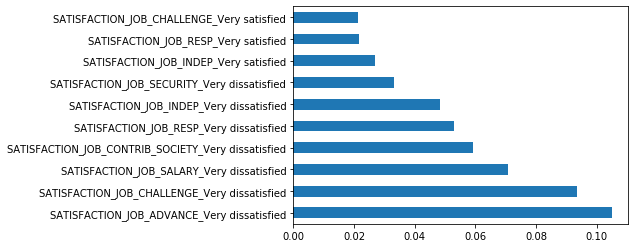

```python
from sklearn.ensemble import RandomForestClassifier
import matplotlib.pyplot as plt
modelvd = RandomForestClassifier(n_estimators=100, random_state=1111)
modelvd.fit(X,yvd)
print(modelvd.feature_importances_) #use inbuilt class feature_importances of tree based classifiers
#plot graph of feature importances for better visualization
feat_importances = pd.Series(modelvd.feature_importances_, index=X.columns)
feat_importances.nlargest(10).plot(kind='barh')
plt.show()
for i in tqdm(range(50)):
    time.sleep(0.1)
```

```python
print(X.columns.values)
```

```
['YEAR' 'GENDER_Female' 'GENDER_Male' 'RACE_Asian'
 'RACE_Under-represented minorities' 'RACE_White'
 'BIRTH_PLACE_Not in the US' 'BIRTH_PLACE_United States'
 'US_CITIZENSHIP_No' 'US_CITIZENSHIP_Yes'
 'US_CITIZEN_TYPE_Born abroad of American parents'
 'US_CITIZEN_TYPE_Born in US or US territories'
 'US_CITIZEN_TYPE_By naturalization' 'US_CITIZEN_TYPE_None'
 'TOTAL_CHILDREN_None' 'TOTAL_CHILDREN_One child'
 'TOTAL_CHILDREN_Two or more children'
 'FIELD_MAJOR_GROUP_BACHELOR_DEGREE_Biological, agricultural and environmental life sciences'
 'FIELD_MAJOR_GROUP_BACHELOR_DEGREE_Computer and mathematical sciences'
 'FIELD_MAJOR_GROUP_BACHELOR_DEGREE_Engineering'
 'FIELD_MAJOR_GROUP_BACHELOR_DEGREE_Non-science and engineering fields'
 'FIELD_MAJOR_GROUP_BACHELOR_DEGREE_Physical and related sciences'
 'FIELD_MAJOR_GROUP_BACHELOR_DEGREE_Science and engineering-related fields'
 'FIELD_MAJOR_GROUP_BACHELOR_DEGREE_Social and related sciences'
 'HIGHEST_DEGREE_Bachelor' 'HIGHEST_DEGREE_Doctorate'
 'HIGHEST_DEGREE_Master' 'HIGHEST_DEGREE_Professional'
 'FIELD_MAJOR_HIGHEST_DEGREE_Biological sciences'
 'FIELD_MAJOR_HIGHEST_DEGREE_Chemical engineering'
 'FIELD_MAJOR_HIGHEST_DEGREE_Chemistry, except biochemistry'
 'FIELD_MAJOR_HIGHEST_DEGREE_Civil engineering'
 'FIELD_MAJOR_HIGHEST_DEGREE_Computer and mathematical science'
 'FIELD_MAJOR_HIGHEST_DEGREE_Economics'
 'FIELD_MAJOR_HIGHEST_DEGREE_Electrical, electronics and communications engineering'
 'FIELD_MAJOR_HIGHEST_DEGREE_Health-related fields'
 'FIELD_MAJOR_HIGHEST_DEGREE_Management and administration'
 'FIELD_MAJOR_HIGHEST_DEGREE_Mechanical engineering'
 'FIELD_MAJOR_HIGHEST_DEGREE_Other biological, agricultural, environmental life sciences'
 'FIELD_MAJOR_HIGHEST_DEGREE_Other engineering'
 'FIELD_MAJOR_HIGHEST_DEGREE_Other non-science and engineering'
 'FIELD_MAJOR_HIGHEST_DEGREE_Other physical and related sciences'
 'FIELD_MAJOR_HIGHEST_DEGREE_Other science and engineering-related'
 'FIELD_MAJOR_HIGHEST_DEGREE_Other social sciences'
 'FIELD_MAJOR_HIGHEST_DEGREE_Physics and astronomy'
 'FIELD_MAJOR_HIGHEST_DEGREE_Political and related sciences'
 'FIELD_MAJOR_HIGHEST_DEGREE_Psychology'
 'FIELD_MAJOR_HIGHEST_DEGREE_Sociology and anthropology'
 'FIELD_MAJOR_GROUP_HIGHEST_DEGREE_Biological, agricultural and environmental life sciences'
 'FIELD_MAJOR_GROUP_HIGHEST_DEGREE_Computer and mathematical sciences'
```

[output cut: 223 more lines]

```
 'ATTEND_TRAINING_For certification' 'ATTEND_TRAINING_Other'
 'ATTEND_TRAINING_Other reason for training'
 'ATTEND_TRAINING_Required or expected by employer'
 'ATTEND_TRAINING_To acquire further skills in my occupational field'
 'ATTEND_TRAINING_To facilitate a change in occupation field'
 'ATTEND_TRAINING_To increase opportunities for promotion, advancement, or higher salary'
 'ATTEND_TRAINING_To learn skills needed for a recently acquired position'
 'ATTEND_TRAINING_CHANGE_FIELD_No' 'ATTEND_TRAINING_CHANGE_FIELD_Yes'
 'ATTEND_TRAINING_BY_EMPLOYER_No' 'ATTEND_TRAINING_BY_EMPLOYER_Yes'
 'ATTEND_TRAINING_CERT_No' 'ATTEND_TRAINING_CERT_Yes'
 'ATTEND_TRAINING_INCREASE_ADV_CUR_No'
 'ATTEND_TRAINING_INCREASE_ADV_CUR_Yes' 'ATTEND_TRAINING_OTHER_No'
 'ATTEND_TRAINING_OTHER_Yes' 'ATTEND_TRAINING_PERSONAL_No'
 'ATTEND_TRAINING_PERSONAL_Yes' 'ATTEND_TRAINING_ACQUIRE_SKILL_No'
 'ATTEND_TRAINING_ACQUIRE_SKILL_Yes']
```

```python
from sklearn.feature_selection import SelectPercentile
from sklearn.feature_selection import f_regression
Selector_f = SelectPercentile (f_regression, percentile = 10)
Selector_f.fit(X, yvd)
for n, s in zip(X, Selector_f.scores_):
    print('F-score: %3.2f\t for feature %s ' %(s,n))
```

```
F-score: 10.98	 for feature YEAR
F-score: 34.45	 for feature GENDER_Female
F-score: 34.45	 for feature GENDER_Male
F-score: 0.28	 for feature RACE_Asian
F-score: 137.58	 for feature RACE_Under-represented minorities
F-score: 110.92	 for feature RACE_White
F-score: 0.10	 for feature BIRTH_PLACE_Not in the US
F-score: 0.10	 for feature BIRTH_PLACE_United States
F-score: 4.29	 for feature US_CITIZENSHIP_No
F-score: 4.29	 for feature US_CITIZENSHIP_Yes
F-score: 0.04	 for feature US_CITIZEN_TYPE_Born abroad of American parents
F-score: 0.07	 for feature US_CITIZEN_TYPE_Born in US or US territories
F-score: 4.65	 for feature US_CITIZEN_TYPE_By naturalization
F-score: 4.29	 for feature US_CITIZEN_TYPE_None
F-score: 100.81	 for feature TOTAL_CHILDREN_None
F-score: 19.96	 for feature TOTAL_CHILDREN_One child
F-score: 57.11	 for feature TOTAL_CHILDREN_Two or more children
F-score: 2.98	 for feature FIELD_MAJOR_GROUP_BACHELOR_DEGREE_Biological, agricultural and environmental life sciences
F-score: 0.63	 for feature FIELD_MAJOR_GROUP_BACHELOR_DEGREE_Computer and mathematical sciences
F-score: 58.87	 for feature FIELD_MAJOR_GROUP_BACHELOR_DEGREE_Engineering
F-score: 0.00	 for feature FIELD_MAJOR_GROUP_BACHELOR_DEGREE_Non-science and engineering fields
F-score: 0.55	 for feature FIELD_MAJOR_GROUP_BACHELOR_DEGREE_Physical and related sciences
F-score: 22.98	 for feature FIELD_MAJOR_GROUP_BACHELOR_DEGREE_Science and engineering-related fields
F-score: 121.78	 for feature FIELD_MAJOR_GROUP_BACHELOR_DEGREE_Social and related sciences
F-score: 93.16	 for feature HIGHEST_DEGREE_Bachelor
F-score: 11.49	 for feature HIGHEST_DEGREE_Doctorate
F-score: 41.08	 for feature HIGHEST_DEGREE_Master
F-score: 15.20	 for feature HIGHEST_DEGREE_Professional
F-score: 17.54	 for feature FIELD_MAJOR_HIGHEST_DEGREE_Biological sciences
F-score: 7.17	 for feature FIELD_MAJOR_HIGHEST_DEGREE_Chemical engineering
F-score: 0.18	 for feature FIELD_MAJOR_HIGHEST_DEGREE_Chemistry, except biochemistry
F-score: 5.24	 for feature FIELD_MAJOR_HIGHEST_DEGREE_Civil engineering
F-score: 0.00	 for feature FIELD_MAJOR_HIGHEST_DEGREE_Computer and mathematical science
F-score: 3.52	 for feature FIELD_MAJOR_HIGHEST_DEGREE_Economics
F-score: 14.48	 for feature FIELD_MAJOR_HIGHEST_DEGREE_Electrical, electronics and communications engineering
F-score: 47.76	 for feature FIELD_MAJOR_HIGHEST_DEGREE_Health-related fields
F-score: 0.77	 for feature FIELD_MAJOR_HIGHEST_DEGREE_Management and administration
F-score: 14.00	 for feature FIELD_MAJOR_HIGHEST_DEGREE_Mechanical engineering
F-score: 0.01	 for feature FIELD_MAJOR_HIGHEST_DEGREE_Other biological, agricultural, environmental life sciences
F-score: 5.45	 for feature FIELD_MAJOR_HIGHEST_DEGREE_Other engineering
```

[output cut: 314 more lines]

```
F-score: 84.31	 for feature ATTEND_TRAINING_To learn skills needed for a recently acquired position
F-score: 25.10	 for feature ATTEND_TRAINING_CHANGE_FIELD_No
F-score: 25.10	 for feature ATTEND_TRAINING_CHANGE_FIELD_Yes
F-score: 66.84	 for feature ATTEND_TRAINING_BY_EMPLOYER_No
F-score: 66.84	 for feature ATTEND_TRAINING_BY_EMPLOYER_Yes
F-score: 146.73	 for feature ATTEND_TRAINING_CERT_No
F-score: 146.73	 for feature ATTEND_TRAINING_CERT_Yes
F-score: 111.89	 for feature ATTEND_TRAINING_INCREASE_ADV_CUR_No
F-score: 111.89	 for feature ATTEND_TRAINING_INCREASE_ADV_CUR_Yes
F-score: 0.00	 for feature ATTEND_TRAINING_OTHER_No
F-score: 0.00	 for feature ATTEND_TRAINING_OTHER_Yes
F-score: 95.44	 for feature ATTEND_TRAINING_PERSONAL_No
F-score: 95.44	 for feature ATTEND_TRAINING_PERSONAL_Yes
F-score: 522.59	 for feature ATTEND_TRAINING_ACQUIRE_SKILL_No
F-score: 522.59	 for feature ATTEND_TRAINING_ACQUIRE_SKILL_Yes
```

```python
#yvd = y['very dissatisfied']

Xvd = X[['SATISFACTION_JOB_RESP_Somewhat satisfied',
'WORK_OUTSIDE_DEGREE_FOR_NOT_AVAIL_No',
'SATISFACTION_JOB_BENEFITS_Very dissatisfied',
'SATISFACTION_JOB_ADVANCE_Very dissatisfied',
'SATISFACTION_JOB_RESP_Very dissatisfied',
'SATISFACTION_JOB_CONTRIB_SOCIETY_Very dissatisfied',
'SATISFACTION_JOB_SECURITY_Very dissatisfied',
'SATISFACTION_JOB_INDEP_Very dissatisfied',
'SATISFACTION_JOB_SALARY_Very dissatisfied',
'SATISFACTION_JOB_CHALLENGE_Very dissatisfied']]
```

```python
X_vdtrain, X_vdtest, y_vdtrain, y_vdtest = train_test_split(Xvd, yvd, test_size = 0.2, random_state =1111)
```

```python
from sklearn.preprocessing import StandardScaler
feature_scaler = StandardScaler()
X_vdtrain = feature_scaler.fit_transform(X_vdtrain)
X_vdtest = feature_scaler.transform(X_vdtest)
```

```python
from sklearn.ensemble import RandomForestClassifier
model_vd_new = RandomForestClassifier(n_estimators=100, random_state=1111)
```

```python
model_vd_new
```

```
RandomForestClassifier(bootstrap=True, class_weight=None, criterion='gini',
                       max_depth=None, max_features='auto', max_leaf_nodes=None,
                       min_impurity_decrease=0.0, min_impurity_split=None,
                       min_samples_leaf=1, min_samples_split=2,
                       min_weight_fraction_leaf=0.0, n_estimators=100,
                       n_jobs=None, oob_score=False, random_state=1111,
                       verbose=0, warm_start=False)
```

```python
model_vd_new.fit(X_vdtrain, y_vdtrain)
```

```
RandomForestClassifier(bootstrap=True, class_weight=None, criterion='gini',
                       max_depth=None, max_features='auto', max_leaf_nodes=None,
                       min_impurity_decrease=0.0, min_impurity_split=None,
                       min_samples_leaf=1, min_samples_split=2,
                       min_weight_fraction_leaf=0.0, n_estimators=100,
                       n_jobs=None, oob_score=False, random_state=1111,
                       verbose=0, warm_start=False)
```

```python
y_predict_vd = model_vd_new.predict(X_vdtest)
```

```python
from sklearn.metrics import classification_report, confusion_matrix
from sklearn.metrics import accuracy_score
accuracy_score(y_vdtest, y_predict_vd)
```

```
0.9794399149237859
```

```python
from sklearn.metrics import classification_report, confusion_matrix

print(confusion_matrix(y_vdtest, y_predict_vd))
print(classification_report(y_vdtest, y_predict_vd))
```

```
[[5273   43]
 [  73  253]]
              precision    recall  f1-score   support

           0       0.99      0.99      0.99      5316
           1       0.85      0.78      0.81       326

    accuracy                           0.98      5642
   macro avg       0.92      0.88      0.90      5642
weighted avg       0.98      0.98      0.98      5642
```

# NOT HAPPY GRIDSEARCHCV

# NOT HAPPY RANDOMIZEDSEARCHCV

```python
from sklearn.model_selection import RandomizedSearchCV
```

```python
# Number of trees in random forest
n_estimators = [int(x) for x in np.linspace(start = 200, stop = 2000, num = 10)]
# Number of features to consider at every split
max_features = ['auto', 'sqrt']
# Maximum number of levels in tree
max_depth = [int(x) for x in np.linspace(10, 110, num = 11)]
max_depth.append(None)
# Minimum number of samples required to split a node
min_samples_split = [2, 5, 10]
# Minimum number of samples required at each leaf node
min_samples_leaf = [1, 2, 4]
# Method of selecting samples for training each tree
bootstrap = [True, False]
```

```python
# Create the random grid
random_gridvd = {'n_estimators': n_estimators,
               'max_features': max_features,
               'max_depth': max_depth,
               'min_samples_split': min_samples_split,
               'min_samples_leaf': min_samples_leaf,
               'bootstrap': bootstrap}
```

```python
pprint(random_gridvd)
```

```
Pretty printing has been turned OFF
```

```python
# Use the random grid to search for best hyperparameters
# First create the base model to tune
rfvd = RandomForestClassifier()
# Random search of parameters, using 3 fold cross validation,
# search across 100 different combinations, and use all available cores
rf_randomvd = RandomizedSearchCV(estimator = rfvd, param_distributions = random_gridvd, n_iter = 100, cv = 5, verbose=2, random_state=1111, n_jobs = -1)
# Fit the random search model
rf_randomvd.fit(X_vdtrain, y_vdtrain)
```

```
Fitting 5 folds for each of 100 candidates, totalling 500 fits
```

```
[Parallel(n_jobs=-1)]: Using backend LokyBackend with 4 concurrent workers.
[Parallel(n_jobs=-1)]: Done  33 tasks      | elapsed:  2.1min
[Parallel(n_jobs=-1)]: Done 154 tasks      | elapsed: 11.7min
[Parallel(n_jobs=-1)]: Done 357 tasks      | elapsed: 23.5min
[Parallel(n_jobs=-1)]: Done 500 out of 500 | elapsed: 35.6min finished
```

```
RandomizedSearchCV(cv=5, error_score='raise-deprecating',
                   estimator=RandomForestClassifier(bootstrap=True,
                                                    class_weight=None,
                                                    criterion='gini',
                                                    max_depth=None,
                                                    max_features='auto',
                                                    max_leaf_nodes=None,
                                                    min_impurity_decrease=0.0,
                                                    min_impurity_split=None,
                                                    min_samples_leaf=1,
                                                    min_samples_split=2,
                                                    min_weight_fraction_leaf=0.0,
                                                    n_estimators='warn',
                                                    n_jobs=None,
                                                    oob_sc...
                   param_distributions={'bootstrap': [True, False],
                                        'max_depth': [10, 20, 30, 40, 50, 60,
                                                      70, 80, 90, 100, 110,
                                                      None],
                                        'max_features': ['auto', 'sqrt'],
                                        'min_samples_leaf': [1, 2, 4],
                                        'min_samples_split': [2, 5, 10],
                                        'n_estimators': [200, 400, 600, 800,
                                                         1000, 1200, 1400, 1600,
                                                         1800, 2000]},
                   pre_dispatch='2*n_jobs', random_state=1111, refit=True,
                   return_train_score=False, scoring=None, verbose=2)
```

```python
rf_randomvd.best_params_
```

```
{'n_estimators': 400, 'min_samples_split': 10, 'min_samples_leaf': 2, 'max_features': 'sqrt', 'max_depth': 40, 'bootstrap': True}
```

```python
bestparamsfromrandomvd = rf_randomvd.best_params_
```

```python
def evaluate(model_vd_new, X_vdtest, y_vdtest):
    predictions = model_vd_new.predict(X_vdtest)
    errors = abs(predictions - y_vdtest)
    mape = 100 * np.mean(errors / y_vdtest)
    accuracy = 100 - mape
    print('Model Performance')
    print('Average Error: {:0.4f} degrees.'.format(np.mean(errors)))
    print('Accuracy = {:0.2f}%.'.format(accuracy))

    return accuracy
base_modelvd = RandomForestClassifier(n_estimators = 10, random_state = 1111)
base_modelvd.fit(X_vdtrain, y_vdtrain)
#base_accuracyvd = evaluate(base_modelvd, X_vdtest, y_vdtest)
#base_accuracyvd = eval(base_modelvd, X_vdtest, y_vdtest)
```

```
RandomForestClassifier(bootstrap=True, class_weight=None, criterion='gini',
                       max_depth=None, max_features='auto', max_leaf_nodes=None,
                       min_impurity_decrease=0.0, min_impurity_split=None,
                       min_samples_leaf=1, min_samples_split=2,
                       min_weight_fraction_leaf=0.0, n_estimators=10,
                       n_jobs=None, oob_score=False, random_state=1111,
                       verbose=0, warm_start=False)
```

```python
#bestparamsfromrandomvdbest_randomvd = rf_randomvd.best_estimator_
#random_accuracyvd = evaluate(best_randomvd, X_vdtest, y_vdtest)
#random_accuracyvd = eval(best_randomvd, X_vdtest, y_vdtest)
```

```python
#( 100 * (random_accuracyvd - base_accuracyvd) / base_accuracyvd))
```

# NOT HAPPY GRIDSEARCHCV

```python
from sklearn.model_selection import GridSearchCV
```

```python
grid_search_cv_vd = GridSearchCV(cv=5, error_score='raise',
             estimator=RandomForestClassifier(bootstrap=True, class_weight=None, criterion='gini',
                       max_depth=None, max_features='auto', max_leaf_nodes=None,
                       min_impurity_decrease=0.0, min_impurity_split=None,
                       min_samples_leaf=1, min_samples_split=2,
                       min_weight_fraction_leaf=0.0, n_estimators=10,
                       n_jobs=None, oob_score=False, random_state=1111,
                       verbose=0, warm_start=False),
                       param_grid={'n_estimators': [200, 500], 'max_features': ['auto', 'sqrt', 'log2'], 'max_depth': [4, 5, 6, 7, 8], 'criterion': ['gini', 'entropy']},
                       pre_dispatch='2*n_jobs', refit=True, return_train_score='warn',
                       scoring=None, verbose=0)
```

```python
grid_search_cv_vd.fit(X_vdtrain, y_vdtrain)
```

```
GridSearchCV(cv=5, error_score='raise',
             estimator=RandomForestClassifier(bootstrap=True, class_weight=None,
                                              criterion='gini', max_depth=None,
                                              max_features='auto',
                                              max_leaf_nodes=None,
                                              min_impurity_decrease=0.0,
                                              min_impurity_split=None,
                                              min_samples_leaf=1,
                                              min_samples_split=2,
                                              min_weight_fraction_leaf=0.0,
                                              n_estimators=10, n_jobs=None,
                                              oob_score=False,
                                              random_state=1111, verbose=0,
                                              warm_start=False),
             iid='warn', n_jobs=None,
             param_grid={'criterion': ['gini', 'entropy'],
                         'max_depth': [4, 5, 6, 7, 8],
                         'max_features': ['auto', 'sqrt', 'log2'],
                         'n_estimators': [200, 500]},
             pre_dispatch='2*n_jobs', refit=True, return_train_score='warn',
             scoring=None, verbose=0)
```

```python
grid_search_cv_vd.best_estimator_
```

```
RandomForestClassifier(bootstrap=True, class_weight=None, criterion='gini',
                       max_depth=5, max_features='auto', max_leaf_nodes=None,
                       min_impurity_decrease=0.0, min_impurity_split=None,
                       min_samples_leaf=1, min_samples_split=2,
                       min_weight_fraction_leaf=0.0, n_estimators=500,
                       n_jobs=None, oob_score=False, random_state=1111,
                       verbose=0, warm_start=False)
```

```python
print(grid_search_cv_vd.best_score_)
```

```
0.9826271937599717
```

```python
print(grid_search_cv_vd.best_params_)
```

```
{'criterion': 'gini', 'max_depth': 5, 'max_features': 'auto', 'n_estimators': 500}
```

```python
my_modelvd = grid_search_cv_vd.best_estimator_
```

```python
my_modelvd
```

```
RandomForestClassifier(bootstrap=True, class_weight=None, criterion='gini',
                       max_depth=5, max_features='auto', max_leaf_nodes=None,
                       min_impurity_decrease=0.0, min_impurity_split=None,
                       min_samples_leaf=1, min_samples_split=2,
                       min_weight_fraction_leaf=0.0, n_estimators=500,
                       n_jobs=None, oob_score=False, random_state=1111,
                       verbose=0, warm_start=False)
```

```python
my_modelvd.fit(X_vdtrain, y_vdtrain)
```

```
RandomForestClassifier(bootstrap=True, class_weight=None, criterion='gini',
                       max_depth=5, max_features='auto', max_leaf_nodes=None,
                       min_impurity_decrease=0.0, min_impurity_split=None,
                       min_samples_leaf=1, min_samples_split=2,
                       min_weight_fraction_leaf=0.0, n_estimators=500,
                       n_jobs=None, oob_score=False, random_state=1111,
                       verbose=0, warm_start=False)
```

```python
y_predict_vd_my_model = my_modelvd.predict(X_vdtest)
```

```python
accuracy_score(y_vdtest, y_predict_vd_my_model)
```

```
0.9806806097128677
```

```python
print(confusion_matrix(y_vdtest, y_predict_vd_my_model))
print(classification_report(y_vdtest, y_predict_vd_my_model))
```

```
[[5280   36]
 [  73  253]]
              precision    recall  f1-score   support

           0       0.99      0.99      0.99      5316
           1       0.88      0.78      0.82       326

    accuracy                           0.98      5642
   macro avg       0.93      0.88      0.91      5642
weighted avg       0.98      0.98      0.98      5642
```

```python
from sklearn import metrics
print('Mean Absolute Error:', metrics.mean_absolute_error(y_vdtest, y_predict_vd_my_model))
print('Mean Squared Error:', metrics.mean_squared_error(y_vdtest, y_predict_vd_my_model))
print('Root Mean Squared Error:', np.sqrt(metrics.mean_squared_error(y_vdtest, y_predict_vd_my_model)))
```

[output not shown]

```python
from sklearn.datasets import *
from sklearn import tree
from dtreeviz.trees import *
from graphviz import Digraph
from graphviz import Graph
```

[figure not shown]

```python
import graphviz
feature_namesvd = ['SATISFACTION_JOB_RESP_Somewhat satisfied',
'WORK_OUTSIDE_DEGREE_FOR_NOT_AVAIL_No',
'SATISFACTION_JOB_BENEFITS_Very dissatisfied',
'SATISFACTION_JOB_ADVANCE_Very dissatisfied',
'SATISFACTION_JOB_RESP_Very dissatisfied',
'SATISFACTION_JOB_CONTRIB_SOCIETY_Very dissatisfied',
'SATISFACTION_JOB_SECURITY_Very dissatisfied',
'SATISFACTION_JOB_INDEP_Very dissatisfied',
'SATISFACTION_JOB_SALARY_Very dissatisfied',
'SATISFACTION_JOB_CHALLENGE_Very dissatisfied']
target_namesvd = ['HAPPY','NOT HAPPY']


fig, axes = plt.subplots(nrows = 1,ncols = 1,figsize = (4,4), dpi=800)
tree.plot_tree(my_modelvd.estimators_[0],
               feature_names = feature_namesvd,
               class_names=target_namesvd,
               filled = True);
fig.savefig('rf_individualtreenothappy.png')
```

# HAPPY EMPLOYEES MODEL

```python
modelmenew = allnewdatanowvd_vs
```

```python
modelmenew = modelmenew.drop('REFID', axis=1)
modelmenew = modelmenew.drop('AGE', axis=1)
```

```python
modelmenew = modelmenew.drop('SALARY_BINS', axis=1)
```

```python
modelmenew = modelmenew.drop('AGE_BINS', axis=1)
```

```python
X = modelmenew.drop('SATISFACTION_JOB', axis=1)
```

```python
y = modelmenew['SATISFACTION_JOB']
```

```python
X = pd.get_dummies(X, prefix_sep='_', drop_first=False)
```

```python
y = pd.get_dummies(y, prefix_sep='_', drop_first=False)
```

```python
X.shape
```

```
(28206, 369)
```

```python
y.shape
```

```
(28206, 2)
```

```python
y.sample(5)
```

|  | Very dissatisfied | Very satisfied |
| --- | --- | --- |
| 49212 | 0 | 1 |
| 47113 | 0 | 1 |
| 68001 | 0 | 1 |
| 65696 | 0 | 1 |
| 63839 | 0 | 1 |

```python
print(X.columns.values)
```

```
['YEAR' 'GENDER_Female' 'GENDER_Male' 'RACE_Asian'
 'RACE_Under-represented minorities' 'RACE_White'
 'BIRTH_PLACE_Not in the US' 'BIRTH_PLACE_United States'
 'US_CITIZENSHIP_No' 'US_CITIZENSHIP_Yes'
 'US_CITIZEN_TYPE_Born abroad of American parents'
 'US_CITIZEN_TYPE_Born in US or US territories'
 'US_CITIZEN_TYPE_By naturalization' 'US_CITIZEN_TYPE_None'
 'TOTAL_CHILDREN_None' 'TOTAL_CHILDREN_One child'
 'TOTAL_CHILDREN_Two or more children'
 'FIELD_MAJOR_GROUP_BACHELOR_DEGREE_Biological, agricultural and environmental life sciences'
 'FIELD_MAJOR_GROUP_BACHELOR_DEGREE_Computer and mathematical sciences'
 'FIELD_MAJOR_GROUP_BACHELOR_DEGREE_Engineering'
 'FIELD_MAJOR_GROUP_BACHELOR_DEGREE_Non-science and engineering fields'
 'FIELD_MAJOR_GROUP_BACHELOR_DEGREE_Physical and related sciences'
 'FIELD_MAJOR_GROUP_BACHELOR_DEGREE_Science and engineering-related fields'
 'FIELD_MAJOR_GROUP_BACHELOR_DEGREE_Social and related sciences'
 'HIGHEST_DEGREE_Bachelor' 'HIGHEST_DEGREE_Doctorate'
 'HIGHEST_DEGREE_Master' 'HIGHEST_DEGREE_Professional'
 'FIELD_MAJOR_HIGHEST_DEGREE_Biological sciences'
 'FIELD_MAJOR_HIGHEST_DEGREE_Chemical engineering'
 'FIELD_MAJOR_HIGHEST_DEGREE_Chemistry, except biochemistry'
 'FIELD_MAJOR_HIGHEST_DEGREE_Civil engineering'
 'FIELD_MAJOR_HIGHEST_DEGREE_Computer and mathematical science'
 'FIELD_MAJOR_HIGHEST_DEGREE_Economics'
 'FIELD_MAJOR_HIGHEST_DEGREE_Electrical, electronics and communications engineering'
 'FIELD_MAJOR_HIGHEST_DEGREE_Health-related fields'
 'FIELD_MAJOR_HIGHEST_DEGREE_Management and administration'
 'FIELD_MAJOR_HIGHEST_DEGREE_Mechanical engineering'
 'FIELD_MAJOR_HIGHEST_DEGREE_Other biological, agricultural, environmental life sciences'
 'FIELD_MAJOR_HIGHEST_DEGREE_Other engineering'
 'FIELD_MAJOR_HIGHEST_DEGREE_Other non-science and engineering'
 'FIELD_MAJOR_HIGHEST_DEGREE_Other physical and related sciences'
 'FIELD_MAJOR_HIGHEST_DEGREE_Other science and engineering-related'
 'FIELD_MAJOR_HIGHEST_DEGREE_Other social sciences'
 'FIELD_MAJOR_HIGHEST_DEGREE_Physics and astronomy'
 'FIELD_MAJOR_HIGHEST_DEGREE_Political and related sciences'
 'FIELD_MAJOR_HIGHEST_DEGREE_Psychology'
 'FIELD_MAJOR_HIGHEST_DEGREE_Sociology and anthropology'
 'FIELD_MAJOR_GROUP_HIGHEST_DEGREE_Biological, agricultural and environmental life sciences'
 'FIELD_MAJOR_GROUP_HIGHEST_DEGREE_Computer and mathematical sciences'
```

[output cut: 223 more lines]

```
 'ATTEND_TRAINING_For certification' 'ATTEND_TRAINING_Other'
 'ATTEND_TRAINING_Other reason for training'
 'ATTEND_TRAINING_Required or expected by employer'
 'ATTEND_TRAINING_To acquire further skills in my occupational field'
 'ATTEND_TRAINING_To facilitate a change in occupation field'
 'ATTEND_TRAINING_To increase opportunities for promotion, advancement, or higher salary'
 'ATTEND_TRAINING_To learn skills needed for a recently acquired position'
 'ATTEND_TRAINING_CHANGE_FIELD_No' 'ATTEND_TRAINING_CHANGE_FIELD_Yes'
 'ATTEND_TRAINING_BY_EMPLOYER_No' 'ATTEND_TRAINING_BY_EMPLOYER_Yes'
 'ATTEND_TRAINING_CERT_No' 'ATTEND_TRAINING_CERT_Yes'
 'ATTEND_TRAINING_INCREASE_ADV_CUR_No'
 'ATTEND_TRAINING_INCREASE_ADV_CUR_Yes' 'ATTEND_TRAINING_OTHER_No'
 'ATTEND_TRAINING_OTHER_Yes' 'ATTEND_TRAINING_PERSONAL_No'
 'ATTEND_TRAINING_PERSONAL_Yes' 'ATTEND_TRAINING_ACQUIRE_SKILL_No'
 'ATTEND_TRAINING_ACQUIRE_SKILL_Yes']
```

```python
y.shape
```

```
(28206, 2)
```

```python
#ysd = y['Somewhat dissatisfied']
```

```python
#yss = y['Somewhat satisfied']
```

```python
yvd = y['Very dissatisfied']
```

```python
yvs = y['Very satisfied']
```

```python
#X_train, X_test, y_sd_train, y_sd_test = train_test_split(X, ysd, test_size = 0.2)
```

```python
#X_train, X_test, y_ss_train, y_sd_test = train_test_split(X, yss, test_size = 0.2)
```

```python
X_train, X_test, y_vd_train, y_sd_test = train_test_split(X, yvd, test_size = 0.2)
```

```python
X_train, X_test, y_vs_train, y_sd_test = train_test_split(X, yvs, test_size = 0.2)
```

```
[1.50748704e-03 1.48208624e-03 1.62160943e-03 8.98100015e-04
 1.46924716e-03 1.48863537e-03 1.10846321e-03 1.11222422e-03
 5.74527164e-04 5.38988847e-04 2.05508291e-04 9.08830048e-04
 9.58713111e-04 7.82673759e-04 1.63608351e-03 9.15664514e-04
 1.35046658e-03 8.21319441e-04 6.34668775e-04 6.87478549e-04
 8.48189111e-04 5.56869827e-04 8.13233318e-04 1.47511681e-03
 1.16726253e-03 5.55217972e-04 1.14426972e-03 6.47451939e-04
 4.99192189e-04 1.36538579e-04 1.37948096e-04 4.32716008e-04
 5.01291533e-04 4.25602442e-04 2.93085514e-04 8.80013791e-04
 5.11684964e-04 4.33052378e-04 4.74677043e-04 6.58939825e-04
 8.20692589e-04 4.91938545e-04 4.16342430e-04 4.62906588e-04
 1.38269959e-04 5.28932982e-04 7.90471064e-04 5.84335665e-04
 7.49414064e-04 4.97471859e-04 8.25818670e-04 9.84552029e-04
 5.24398894e-04 8.45911561e-04 1.05869732e-03 9.75436322e-04
 2.00930121e-04 1.16077442e-03 6.32368240e-04 6.33522191e-04
 5.22325710e-04 2.44088688e-04 2.67107407e-04 3.94468763e-04
 5.12655166e-04 3.04696125e-04 3.26776053e-04 7.22314998e-04
 5.18998127e-04 3.55739759e-04 5.10596512e-04 5.11790174e-04
 8.46730903e-04 4.36849006e-04 3.50689372e-04 1.16665838e-04
 5.72272405e-04 7.93899687e-04 6.09823943e-04 7.33079230e-04
 5.26679929e-04 6.72283077e-04 8.87170000e-04 4.79708543e-04
 8.84124669e-04 1.00436254e-03 4.89293933e-04 5.75496459e-04
 5.15958695e-04 5.57242182e-04 7.87363472e-04 6.92334802e-04
 4.30911954e-04 5.35938760e-04 4.41187061e-04 4.34994896e-04
 6.26070431e-04 5.77314478e-04 6.30343851e-04 5.47653769e-04
 3.56415304e-04 4.14331261e-04 8.65067369e-04 8.56208257e-04
 1.47822304e-03 1.54105955e-03 2.11749378e-04 2.18070429e-04
 5.42462164e-04 6.39836584e-04 1.45072866e-03 1.70137599e-03
 1.53649455e-03 1.35162807e-03 1.07831138e-03 1.26127382e-03
 1.20903280e-03 1.19674209e-03 3.39985849e-03 2.95249033e-03
 1.55777173e-03 2.36095946e-04 5.95069569e-05 2.38934015e-04
 2.42609190e-04 7.15746728e-04 9.72131863e-05 2.68044773e-04
 8.72006027e-04 3.95412253e-04 6.45877641e-04 1.57773880e-03
 4.21583316e-04 2.30741311e-04 7.29607396e-04 3.14372833e-04
 1.18143990e-04 1.01745737e-04 1.10400653e-04 1.60327105e-04
 6.89662818e-05 7.02528738e-05 1.54869837e-04 2.17444596e-04
 6.80034103e-04 5.16752625e-04 2.45326447e-04 3.19725868e-04
 8.80836679e-04 6.93394578e-04 1.27129627e-03 3.54334267e-04
 1.07751973e-03 4.11995380e-04 7.01026612e-04 1.12364249e-03
 1.71990358e-03 9.07377890e-04 1.74519392e-04 1.02830300e-03
```

[output cut: 38 more lines]

```
 6.92056876e-03 1.31386050e-03 1.72059790e-03 1.50236296e-02
 5.81148013e-03 7.74782858e-03 6.69339078e-03 9.34210555e-02
 2.13764276e-02 9.20623592e-03 5.07105835e-03 4.83727980e-02
 2.67720534e-02 1.39579075e-03 1.83398375e-03 1.57815879e-02
 7.52757584e-03 1.68681897e-02 9.53932016e-03 5.29836961e-02
 2.16591342e-02 3.40792686e-03 4.83708335e-03 7.09212806e-02
 7.52809778e-03 2.18979214e-03 1.72323148e-03 3.31616483e-02
 6.82551723e-03 5.95068875e-03 2.61024424e-03 5.93164297e-02
 1.72387475e-02 1.08541040e-03 1.35149452e-03 8.59426667e-04
 1.59596675e-03 5.71061422e-05 1.13398165e-04 2.85448373e-04
 1.84339778e-03 5.53418905e-04 1.50864589e-03 7.08238987e-04
 7.50223410e-04 1.25142627e-03 1.11388192e-03 1.22642639e-03
 9.88433052e-04 8.91985189e-04 1.00752997e-03 1.85927738e-04
 1.67346337e-04 8.04760069e-04 1.12477893e-03 1.82914549e-03
 1.71264161e-03]
```

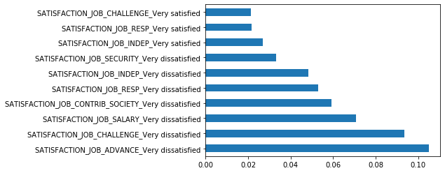

```python
from sklearn.ensemble import RandomForestClassifier
import matplotlib.pyplot as plt
modelvs = RandomForestClassifier(n_estimators=100, random_state=1111)
modelvs.fit(X,yvs)
print(modelvs.feature_importances_) #use inbuilt class feature_importances of tree based classifiers
#plot graph of feature importances for better visualization
feat_importances = pd.Series(modelvs.feature_importances_, index=X.columns)
feat_importances.nlargest(10).plot(kind='barh')
plt.show()
for i in tqdm(range(50)):
    time.sleep(0.1)
```

```python
print(X.columns.values)
```

```
['YEAR' 'GENDER_Female' 'GENDER_Male' 'RACE_Asian'
 'RACE_Under-represented minorities' 'RACE_White'
 'BIRTH_PLACE_Not in the US' 'BIRTH_PLACE_United States'
 'US_CITIZENSHIP_No' 'US_CITIZENSHIP_Yes'
 'US_CITIZEN_TYPE_Born abroad of American parents'
 'US_CITIZEN_TYPE_Born in US or US territories'
 'US_CITIZEN_TYPE_By naturalization' 'US_CITIZEN_TYPE_None'
 'TOTAL_CHILDREN_None' 'TOTAL_CHILDREN_One child'
 'TOTAL_CHILDREN_Two or more children'
 'FIELD_MAJOR_GROUP_BACHELOR_DEGREE_Biological, agricultural and environmental life sciences'
 'FIELD_MAJOR_GROUP_BACHELOR_DEGREE_Computer and mathematical sciences'
 'FIELD_MAJOR_GROUP_BACHELOR_DEGREE_Engineering'
 'FIELD_MAJOR_GROUP_BACHELOR_DEGREE_Non-science and engineering fields'
 'FIELD_MAJOR_GROUP_BACHELOR_DEGREE_Physical and related sciences'
 'FIELD_MAJOR_GROUP_BACHELOR_DEGREE_Science and engineering-related fields'
 'FIELD_MAJOR_GROUP_BACHELOR_DEGREE_Social and related sciences'
 'HIGHEST_DEGREE_Bachelor' 'HIGHEST_DEGREE_Doctorate'
 'HIGHEST_DEGREE_Master' 'HIGHEST_DEGREE_Professional'
 'FIELD_MAJOR_HIGHEST_DEGREE_Biological sciences'
 'FIELD_MAJOR_HIGHEST_DEGREE_Chemical engineering'
 'FIELD_MAJOR_HIGHEST_DEGREE_Chemistry, except biochemistry'
 'FIELD_MAJOR_HIGHEST_DEGREE_Civil engineering'
 'FIELD_MAJOR_HIGHEST_DEGREE_Computer and mathematical science'
 'FIELD_MAJOR_HIGHEST_DEGREE_Economics'
 'FIELD_MAJOR_HIGHEST_DEGREE_Electrical, electronics and communications engineering'
 'FIELD_MAJOR_HIGHEST_DEGREE_Health-related fields'
 'FIELD_MAJOR_HIGHEST_DEGREE_Management and administration'
 'FIELD_MAJOR_HIGHEST_DEGREE_Mechanical engineering'
 'FIELD_MAJOR_HIGHEST_DEGREE_Other biological, agricultural, environmental life sciences'
 'FIELD_MAJOR_HIGHEST_DEGREE_Other engineering'
 'FIELD_MAJOR_HIGHEST_DEGREE_Other non-science and engineering'
 'FIELD_MAJOR_HIGHEST_DEGREE_Other physical and related sciences'
 'FIELD_MAJOR_HIGHEST_DEGREE_Other science and engineering-related'
 'FIELD_MAJOR_HIGHEST_DEGREE_Other social sciences'
 'FIELD_MAJOR_HIGHEST_DEGREE_Physics and astronomy'
 'FIELD_MAJOR_HIGHEST_DEGREE_Political and related sciences'
 'FIELD_MAJOR_HIGHEST_DEGREE_Psychology'
 'FIELD_MAJOR_HIGHEST_DEGREE_Sociology and anthropology'
 'FIELD_MAJOR_GROUP_HIGHEST_DEGREE_Biological, agricultural and environmental life sciences'
 'FIELD_MAJOR_GROUP_HIGHEST_DEGREE_Computer and mathematical sciences'
```

[output cut: 223 more lines]

```
 'ATTEND_TRAINING_For certification' 'ATTEND_TRAINING_Other'
 'ATTEND_TRAINING_Other reason for training'
 'ATTEND_TRAINING_Required or expected by employer'
 'ATTEND_TRAINING_To acquire further skills in my occupational field'
 'ATTEND_TRAINING_To facilitate a change in occupation field'
 'ATTEND_TRAINING_To increase opportunities for promotion, advancement, or higher salary'
 'ATTEND_TRAINING_To learn skills needed for a recently acquired position'
 'ATTEND_TRAINING_CHANGE_FIELD_No' 'ATTEND_TRAINING_CHANGE_FIELD_Yes'
 'ATTEND_TRAINING_BY_EMPLOYER_No' 'ATTEND_TRAINING_BY_EMPLOYER_Yes'
 'ATTEND_TRAINING_CERT_No' 'ATTEND_TRAINING_CERT_Yes'
 'ATTEND_TRAINING_INCREASE_ADV_CUR_No'
 'ATTEND_TRAINING_INCREASE_ADV_CUR_Yes' 'ATTEND_TRAINING_OTHER_No'
 'ATTEND_TRAINING_OTHER_Yes' 'ATTEND_TRAINING_PERSONAL_No'
 'ATTEND_TRAINING_PERSONAL_Yes' 'ATTEND_TRAINING_ACQUIRE_SKILL_No'
 'ATTEND_TRAINING_ACQUIRE_SKILL_Yes']
```

```python
#Xvs = X[['SATISFACTION_JOB_RESP_Somewhat satisfied','SATISFACTION_JOB_BENEFITS_Very satisfied','SATISFACTION_JOB_SECURITY_Very satisfied','SATISFACTION_JOB_CHALLENGE_Very satisfied','SATISFACTION_JOB_ADVANCE_Very satisfied','SATISFACTION_JOB_CONTRIB_SOCIETY_Very satisfied','SATISFACTION_JOB_SALARY_Very satisfied','SATISFACTION_JOB_INDEP_Very satisfied','SATISFACTION_JOB_RESP_Very satisfied']]
Xvs = X[['SATISFACTION_JOB_SECURITY_Very satisfied','SATISFACTION_JOB_CHALLENGE_Very satisfied','SATISFACTION_JOB_ADVANCE_Very satisfied','SATISFACTION_JOB_CONTRIB_SOCIETY_Very satisfied','SATISFACTION_JOB_SALARY_Very satisfied','SATISFACTION_JOB_INDEP_Very satisfied','SATISFACTION_JOB_RESP_Very satisfied']]
```

```python
X_vstrain, X_vstest, y_vstrain, y_vstest = train_test_split(Xvs, yvs, test_size = 0.2, random_state =1111)
```

```python
from sklearn.preprocessing import StandardScaler
feature_scaler = StandardScaler()
X_vstrain = feature_scaler.fit_transform(X_vstrain)
X_vstest = feature_scaler.transform(X_vstest)
```

```python
from sklearn.ensemble import RandomForestClassifier
model_vs_new = RandomForestClassifier(n_estimators=100, random_state=1111)
```

```python
model_vs_new
```

```
RandomForestClassifier(bootstrap=True, class_weight=None, criterion='gini',
                       max_depth=None, max_features='auto', max_leaf_nodes=None,
                       min_impurity_decrease=0.0, min_impurity_split=None,
                       min_samples_leaf=1, min_samples_split=2,
                       min_weight_fraction_leaf=0.0, n_estimators=100,
                       n_jobs=None, oob_score=False, random_state=1111,
                       verbose=0, warm_start=False)
```

```python
model_vs_new.fit(X_vstrain, y_vstrain)
```

```
RandomForestClassifier(bootstrap=True, class_weight=None, criterion='gini',
                       max_depth=None, max_features='auto', max_leaf_nodes=None,
                       min_impurity_decrease=0.0, min_impurity_split=None,
                       min_samples_leaf=1, min_samples_split=2,
                       min_weight_fraction_leaf=0.0, n_estimators=100,
                       n_jobs=None, oob_score=False, random_state=1111,
                       verbose=0, warm_start=False)
```

```python
y_predict_vs = model_vs_new.predict(X_vstest)
```

```python
from sklearn.metrics import classification_report, confusion_matrix
from sklearn.metrics import accuracy_score
accuracy_score(y_vstest, y_predict_vs)
```

```
0.9624246721020915
```

```python
from sklearn.metrics import classification_report, confusion_matrix

print(confusion_matrix(y_vstest, y_predict_vs))
print(classification_report(y_vstest, y_predict_vs))
```

```
[[ 203  123]
 [  89 5227]]
              precision    recall  f1-score   support

           0       0.70      0.62      0.66       326
           1       0.98      0.98      0.98      5316

    accuracy                           0.96      5642
   macro avg       0.84      0.80      0.82      5642
weighted avg       0.96      0.96      0.96      5642
```

# HAPPY RANDOMIZEDSEARCHCV

```python
from sklearn.model_selection import RandomizedSearchCV
```

```python
# Number of trees in random forest
n_estimators = [int(x) for x in np.linspace(start = 200, stop = 2000, num = 10)]
# Number of features to consider at every split
max_features = ['auto', 'sqrt']
# Maximum number of levels in tree
max_depth = [int(x) for x in np.linspace(10, 110, num = 11)]
max_depth.append(None)
# Minimum number of samples required to split a node
min_samples_split = [2, 5, 10]
# Minimum number of samples required at each leaf node
min_samples_leaf = [1, 2, 4]
# Method of selecting samples for training each tree
bootstrap = [True, False]
```

```python
# Create the random grid
random_gridvs = {'n_estimators': n_estimators,
               'max_features': max_features,
               'max_depth': max_depth,
               'min_samples_split': min_samples_split,
               'min_samples_leaf': min_samples_leaf,
               'bootstrap': bootstrap}
```

```python
pprint(random_gridvs)
```

```
Pretty printing has been turned ON
```

```python
# Use the random grid to search for best hyperparameters
# First create the base model to tune
rfvs = RandomForestClassifier()
# Random search of parameters, using 3 fold cross validation,
# search across 100 different combinations, and use all available cores
rf_randomvs = RandomizedSearchCV(estimator = rfvs, param_distributions = random_gridvs, n_iter = 100, cv = 5, verbose=2, random_state=1111, n_jobs = -1)
# Fit the random search model
rf_randomvs.fit(X_vstrain, y_vstrain)
#model_vs_new
#X_vstrain, X_vstest, y_vstrain, y_vstest
```

```
Fitting 5 folds for each of 100 candidates, totalling 500 fits
```

```
[Parallel(n_jobs=-1)]: Using backend LokyBackend with 4 concurrent workers.
[Parallel(n_jobs=-1)]: Done  33 tasks      | elapsed:  1.8min
[Parallel(n_jobs=-1)]: Done 154 tasks      | elapsed: 10.3min
[Parallel(n_jobs=-1)]: Done 357 tasks      | elapsed: 20.7min
[Parallel(n_jobs=-1)]: Done 500 out of 500 | elapsed: 31.1min finished
```

```
RandomizedSearchCV(cv=5, error_score='raise-deprecating',
                   estimator=RandomForestClassifier(bootstrap=True,
                                                    class_weight=None,
                                                    criterion='gini',
                                                    max_depth=None,
                                                    max_features='auto',
                                                    max_leaf_nodes=None,
                                                    min_impurity_decrease=0.0,
                                                    min_impurity_split=None,
                                                    min_samples_leaf=1,
                                                    min_samples_split=2,
                                                    min_weight_fraction_leaf=0.0,
                                                    n_estimators='warn',
                                                    n_jobs=None,
                                                    oob_sc...
                   param_distributions={'bootstrap': [True, False],
                                        'max_depth': [10, 20, 30, 40, 50, 60,
                                                      70, 80, 90, 100, 110,
                                                      None],
                                        'max_features': ['auto', 'sqrt'],
                                        'min_samples_leaf': [1, 2, 4],
                                        'min_samples_split': [2, 5, 10],
                                        'n_estimators': [200, 400, 600, 800,
                                                         1000, 1200, 1400, 1600,
                                                         1800, 2000]},
                   pre_dispatch='2*n_jobs', random_state=1111, refit=True,
                   return_train_score=False, scoring=None, verbose=2)
```

```python
rf_randomvs.best_params_
```

```
{'n_estimators': 400,
 'min_samples_split': 5,
 'min_samples_leaf': 4,
 'max_features': 'sqrt',
 'max_depth': 100,
 'bootstrap': False}
```

```python
def evaluate(model_vs_new, X_vstest, y_vstest):
    predictions = model_vs_new.predict(X_vstest)
    errors = abs(predictions - y_vstest)
    mape = 100 * np.mean(errors / y_vstest)
    accuracy = 100 - mape
    print('Model Performance')
    print('Average Error: {:0.4f} degrees.'.format(np.mean(errors)))
    print('Accuracy = {:0.2f}%.'.format(accuracy))

    return accuracy
base_modelvs = RandomForestClassifier(n_estimators = 10, random_state = 1111)
base_modelvs.fit(X_vstrain, y_vstrain)
#base_accuracyvs = evaluate(base_modelvs, X_vstest, y_vstest)
#base_accuracyvs = eval(base_modelvs, X_vstest, y_vstest)
```

```
RandomForestClassifier(bootstrap=True, class_weight=None, criterion='gini',
                       max_depth=None, max_features='auto', max_leaf_nodes=None,
                       min_impurity_decrease=0.0, min_impurity_split=None,
                       min_samples_leaf=1, min_samples_split=2,
                       min_weight_fraction_leaf=0.0, n_estimators=10,
                       n_jobs=None, oob_score=False, random_state=1111,
                       verbose=0, warm_start=False)
```

```python
rf_randomvs.best_estimator_
#random_accuracyvs = evaluate(best_randomvs, X_vstest, y_vstest)
#random_accuracyvs = eval(best_randomvs, X_vstest, y_vstest)
```

```
RandomForestClassifier(bootstrap=False, class_weight=None, criterion='gini',
                       max_depth=100, max_features='sqrt', max_leaf_nodes=None,
                       min_impurity_decrease=0.0, min_impurity_split=None,
                       min_samples_leaf=4, min_samples_split=5,
                       min_weight_fraction_leaf=0.0, n_estimators=400,
                       n_jobs=None, oob_score=False, random_state=None,
                       verbose=0, warm_start=False)
```

```python
#print('Improvement of {:0.2f}%.'.format( 100 * (random_accuracyvs - base_accuracyvs) / base_accuracyvs))
```